# Pandemic associated changes in cognition from the CLSA Comprehensive Cohort

```r
    #Animal Fluency
    Animal_Fluency_Predicted_0 = case_when(
      Sex_0 =="M" & Education4_0 == "Less than High School Diploma" & Animal_Fluency_Lang_0=="English" ~ 23.132 - 0.095*Age_0,
      Sex_0 =="M" & Education4_0 == "High School Diploma" & Animal_Fluency_Lang_0=="English" ~ 28.923 - 0.157*Age_0,
      Sex_0 =="M" & Education4_0 == "Some College" & Animal_Fluency_Lang_0=="English" ~ 32.513 - 0.202*Age_0,
      Sex_0 =="M" & Education4_0 == "College Degree or Higher" & Animal_Fluency_Lang_0=="English" ~ 31.143 - 0.168*Age_0,
      Sex_0 =="F" & Education4_0 == "Less than High School Diploma" & Animal_Fluency_Lang_0=="English" ~ 23.433 - 0.114*Age_0,
      Sex_0 =="F" & Education4_0 == "High School Diploma" & Animal_Fluency_Lang_0=="English" ~ 29.912 - 0.181*Age_0,
      Sex_0 =="F" & Education4_0 == "Some College" & Animal_Fluency_Lang_0=="English" ~ 30.764 - 0.178*Age_0,
      Sex_0 =="F" & Education4_0 == "College Degree or Higher" & Animal_Fluency_Lang_0=="English" ~ 32.003 - 0.186*Age_0,
      Sex_0 =="M" & Education4_0 == "Less than High School Diploma" & Animal_Fluency_Lang_0=="French" ~ 26.034 - 0.152*Age_0,
      Sex_0 =="M" & Education4_0 == "High School Diploma" & Animal_Fluency_Lang_0=="French" ~ 33.358 - 0.241*Age_0,
      Sex_0 =="M" & Education4_0 == "Some College" & Animal_Fluency_Lang_0=="French" ~ 36.511 - 0.277*Age_0,
      Sex_0 =="M" & Education4_0 == "College Degree or Higher" & Animal_Fluency_Lang_0=="French" ~ 30.193 - 0.179*Age_0,
      Sex_0 =="F" & Education4_0 == "Less than High School Diploma" & Animal_Fluency_Lang_0=="French" ~ 21.460 - 0.089*Age_0,
      Sex_0 =="F" & Education4_0 == "High School Diploma" & Animal_Fluency_Lang_0=="French" ~ 21.355 - 0.070*Age_0,
      Sex_0 =="F" & Education4_0 == "Some College" & Animal_Fluency_Lang_0=="French" ~ 30.881 - 0.205*Age_0,
      Sex_0 =="F" & Education4_0 == "College Degree or Higher" & Animal_Fluency_Lang_0=="French" ~ 29.961 - 0.180*Age_0
    ),
    Animal_Fluency_Residual_0 = Animal_Fluency_Lenient_0 - Animal_Fluency_Predicted_0,
    Animal_Fluency_Z_0 = case_when(
      Sex_0 =="M" & Education4_0 == "Less than High School Diploma" & Animal_Fluency_Lang_0=="English" ~ Animal_Fluency_Residual_0/5.145,
      Sex_0 =="M" & Education4_0 == "High School Diploma" & Animal_Fluency_Lang_0=="English" ~ Animal_Fluency_Residual_0/5.348,
      Sex_0 =="M" & Education4_0 == "Some College" & Animal_Fluency_Lang_0=="English" ~ Animal_Fluency_Residual_0/5.163,
      Sex_0 =="M" & Education4_0 == "College Degree or Higher" & Animal_Fluency_Lang_0=="English" ~ Animal_Fluency_Residual_0/5.354,
      Sex_0 =="F" & Education4_0 == "Less than High School Diploma" & Animal_Fluency_Lang_0=="English" ~ Animal_Fluency_Residual_0/4.665,
      Sex_0 =="F" & Education4_0 == "High School Diploma" & Animal_Fluency_Lang_0=="English" ~ Animal_Fluency_Residual_0/4.728,
      Sex_0 =="F" & Education4_0 == "Some College" & Animal_Fluency_Lang_0=="English" ~ Animal_Fluency_Residual_0/5.176,
      Sex_0 =="F" & Education4_0 == "College Degree or Higher" & Animal_Fluency_Lang_0=="English" ~ Animal_Fluency_Residual_0/5.369,
      Sex_0 =="M" & Education4_0 == "Less than High School Diploma" & Animal_Fluency_Lang_0=="French" ~ Animal_Fluency_Residual_0/3.911,
      Sex_0 =="M" & Education4_0 == "High School Diploma" & Animal_Fluency_Lang_0=="French" ~ Animal_Fluency_Residual_0/4.889,
      Sex_0 =="M" & Education4_0 == "Some College" & Animal_Fluency_Lang_0=="French" ~ Animal_Fluency_Residual_0/5.061,
      Sex_0 =="M" & Education4_0 == "College Degree or Higher" & Animal_Fluency_Lang_0=="French" ~ Animal_Fluency_Residual_0/4.869,
      Sex_0 =="F" & Education4_0 == "Less than High School Diploma" & Animal_Fluency_Lang_0=="French" ~ Animal_Fluency_Residual_0/4.178,
      Sex_0 =="F" & Education4_0 == "High School Diploma" & Animal_Fluency_Lang_0=="French" ~ Animal_Fluency_Residual_0/4.321,
      Sex_0 =="F" & Education4_0 == "Some College" & Animal_Fluency_Lang_0=="French" ~ Animal_Fluency_Residual_0/4.468,
      Sex_0 =="F" & Education4_0 == "College Degree or Higher" & Animal_Fluency_Lang_0=="French" ~ Animal_Fluency_Residual_0/4.940
    ),
    Animal_Fluency_Normed_0 = Animal_Fluency_Z_0*3 +10,
    Animal_Fluency_Normed_0 = if_else(Animal_Fluency_Normed_0 < 0, 0.01, Animal_Fluency_Normed_0),

    #Mental Alteration Test
    MAT_Predicted_0 = case_when(
      Sex_0 =="M" & Education4_0 == "Less than High School Diploma" & MAT_Lang_0=="English" ~ 33.295 - 0.161*Age_0,
      Sex_0 =="M" & Education4_0 == "High School Diploma" & MAT_Lang_0=="English" ~ 34.074 - 0.123*Age_0,
      Sex_0 =="M" & Education4_0 == "Some College" & MAT_Lang_0=="English" ~ 41.488 - 0.219*Age_0,
      Sex_0 =="M" & Education4_0 == "College Degree or Higher" & MAT_Lang_0=="English" ~ 40.573 - 0.190*Age_0,
      Sex_0 =="F" & Education4_0 == "Less than High School Diploma" & MAT_Lang_0=="English" ~ 39.102 - 0.251*Age_0,
      Sex_0 =="F" & Education4_0 == "High School Diploma" & MAT_Lang_0=="English" ~ 41.657 - 0.246*Age_0,
      Sex_0 =="F" & Education4_0 == "Some College" & MAT_Lang_0=="English" ~ 36.877 - 0.168*Age_0,
      Sex_0 =="F" & Education4_0 == "College Degree or Higher" & MAT_Lang_0=="English" ~ 38.849 - 0.188*Age_0,
      Sex_0 =="M" & Education4_0 == "Less than High School Diploma" & MAT_Lang_0=="French" ~ 36.630 - 0.252*Age_0,
      Sex_0 =="M" & Education4_0 == "High School Diploma" & MAT_Lang_0=="French" ~ 38.784 - 0.181*Age_0,
      Sex_0 =="M" & Education4_0 == "Some College" & MAT_Lang_0=="French" ~ 51.105 - 0.381*Age_0,
      Sex_0 =="M" & Education4_0 == "College Degree or Higher" & MAT_Lang_0=="French" ~ 44.106 - 0.257*Age_0,
      Sex_0 =="F" & Education4_0 == "Less than High School Diploma" & MAT_Lang_0=="French" ~ 34.814 - 0.214*Age_0,
      Sex_0 =="F" & Education4_0 == "High School Diploma" & MAT_Lang_0=="French" ~ 38.756 - 0.202*Age_0,
      Sex_0 =="F" & Education4_0 == "Some College" & MAT_Lang_0=="French" ~ 47.024 - 0.315*Age_0,
      Sex_0 =="F" & Education4_0 == "College Degree or Higher" & MAT_Lang_0=="French" ~ 41.717 - 0.234*Age_0
    ),
    MAT_Residual_0 = MAT_Score_0 - MAT_Predicted_0,
    MAT_Z_0 = case_when(
      Sex_0 =="M" & Education4_0 == "Less than High School Diploma" & MAT_Lang_0=="English" ~ MAT_Residual_0/7.602,
      Sex_0 =="M" & Education4_0 == "High School Diploma" & MAT_Lang_0=="English" ~ MAT_Residual_0/7.702,
      Sex_0 =="M" & Education4_0 == "Some College" & MAT_Lang_0=="English" ~ MAT_Residual_0/7.490,
      Sex_0 =="M" & Education4_0 == "College Degree or Higher" & MAT_Lang_0=="English" ~ MAT_Residual_0/7.727,
      Sex_0 =="F" & Education4_0 == "Less than High School Diploma" & MAT_Lang_0=="English" ~ MAT_Residual_0/7.080,
      Sex_0 =="F" & Education4_0 == "High School Diploma" & MAT_Lang_0=="English" ~ MAT_Residual_0/7.139,
      Sex_0 =="F" & Education4_0 == "Some College" & MAT_Lang_0=="English" ~ MAT_Residual_0/6.915,
      Sex_0 =="F" & Education4_0 == "College Degree or Higher" & MAT_Lang_0=="English" ~ MAT_Residual_0/6.979,
      Sex_0 =="M" & Education4_0 == "Less than High School Diploma" & MAT_Lang_0=="French" ~ MAT_Residual_0/7.589,
      Sex_0 =="M" & Education4_0 == "High School Diploma" & MAT_Lang_0=="French" ~ MAT_Residual_0/7.234,
      Sex_0 =="M" & Education4_0 == "Some College" & MAT_Lang_0=="French" ~ MAT_Residual_0/6.314,
      Sex_0 =="M" & Education4_0 == "College Degree or Higher" & MAT_Lang_0=="French" ~ MAT_Residual_0/7.609,
      Sex_0 =="F" & Education4_0 == "Less than High School Diploma" & MAT_Lang_0=="French" ~ MAT_Residual_0/6.803,
      Sex_0 =="F" & Education4_0 == "High School Diploma" & MAT_Lang_0=="French" ~ MAT_Residual_0/7.079,
      Sex_0 =="F" & Education4_0 == "Some College" & MAT_Lang_0=="French" ~ MAT_Residual_0/6.451,
      Sex_0 =="F" & Education4_0 == "College Degree or Higher" & MAT_Lang_0=="French" ~ MAT_Residual_0/6.734
    ),
    MAT_Normed_0 = MAT_Z_0*3 +10,
    MAT_Normed_0 = if_else(MAT_Normed_0 < 0, 0.01, MAT_Normed_0),
```

```r
    #Global Cognition Composite Score
    Global_Composite_0 = RVLT_Immediate_Z_0 + RVLT_Delayed_Z_0 + Animal_Fluency_Z_0 + MAT_Z_0,

    #FU1 Scores

    #RVLT Immediate Score
    RVLT_Immediate_Predicted_1 = case_when(
      Sex_1 =="M" & Education4_1 == "Less than High School Diploma" & RVLT_Immediate_Lang_1=="English" ~ 7.768 - 0.050*Age_1,
      Sex_1 =="M" & Education4_1 == "High School Diploma" & RVLT_Immediate_Lang_1=="English" ~ 7.449 - 0.036*Age_1,
      Sex_1 =="M" & Education4_1 == "Some College" & RVLT_Immediate_Lang_1=="English" ~ 10.095 - 0.073*Age_1,
      Sex_1 =="M" & Education4_1 == "College Degree or Higher" & RVLT_Immediate_Lang_1=="English" ~ 9.686 - 0.064*Age_1,
      Sex_1 =="F" & Education4_1 == "Less than High School Diploma" & RVLT_Immediate_Lang_1=="English" ~ 8.077 - 0.043*Age_1,
      Sex_1 =="F" & Education4_1 == "High School Diploma" & RVLT_Immediate_Lang_1=="English" ~ 9.806 - 0.059*Age_1,
      Sex_1 =="F" & Education4_1 == "Some College" & RVLT_Immediate_Lang_1=="English" ~ 9.161 - 0.047*Age_1,
      Sex_1 =="F" & Education4_1 == "College Degree or Higher" & RVLT_Immediate_Lang_1=="English" ~ 9.804 - 0.053*Age_1,
      Sex_1 =="M" & Education4_1 == "Less than High School Diploma" & RVLT_Immediate_Lang_1=="French" ~ 5.666 - 0.025*Age_1,
      Sex_1 =="M" & Education4_1 == "High School Diploma" & RVLT_Immediate_Lang_1=="French" ~ 8.953 - 0.067*Age_1,
      Sex_1 =="M" & Education4_1 == "Some College" & RVLT_Immediate_Lang_1=="French" ~ 7.662 - 0.039*Age_1,
      Sex_1 =="M" & Education4_1 == "College Degree or Higher" & RVLT_Immediate_Lang_1=="French" ~ 8.829 - 0.057*Age_1,
      Sex_1 =="F" & Education4_1 == "Less than High School Diploma" & RVLT_Immediate_Lang_1=="French" ~ 6.976 - 0.031*Age_1,
      Sex_1 =="F" & Education4_1 == "High School Diploma" & RVLT_Immediate_Lang_1=="French" ~ 8.667 - 0.045*Age_1,
      Sex_1 =="F" & Education4_1 == "Some College" & RVLT_Immediate_Lang_1=="French" ~ 9.502 - 0.061*Age_1,
      Sex_1 =="F" & Education4_1 == "College Degree or Higher" & RVLT_Immediate_Lang_1=="French" ~ 9.013 - 0.047*Age_1
    ),
    RVLT_Immediate_Residual_1 = RVLT_Immediate_Score_1 - RVLT_Immediate_Predicted_1,
    RVLT_Immediate_Z_1 = case_when(
      Sex_1 =="M" & Education4_1 == "Less than High School Diploma" & RVLT_Immediate_Lang_1=="English" ~ RVLT_Immediate_Residual_1/1.471,
      Sex_1 =="M" & Education4_1 == "High School Diploma" & RVLT_Immediate_Lang_1=="English" ~ RVLT_Immediate_Residual_1/1.525,
      Sex_1 =="M" & Education4_1 == "Some College" & RVLT_Immediate_Lang_1=="English" ~ RVLT_Immediate_Residual_1/1.611,
      Sex_1 =="M" & Education4_1 == "College Degree or Higher" & RVLT_Immediate_Lang_1=="English" ~ RVLT_Immediate_Residual_1/1.675,
      Sex_1 =="F" & Education4_1 == "Less than High School Diploma" & RVLT_Immediate_Lang_1=="English" ~ RVLT_Immediate_Residual_1/1.528,
      Sex_1 =="F" & Education4_1 == "High School Diploma" & RVLT_Immediate_Lang_1=="English" ~ RVLT_Immediate_Residual_1/1.643,
      Sex_1 =="F" & Education4_1 == "Some College" & RVLT_Immediate_Lang_1=="English" ~ RVLT_Immediate_Residual_1/1.694,
      Sex_1 =="F" & Education4_1 == "College Degree or Higher" & RVLT_Immediate_Lang_1=="English" ~ RVLT_Immediate_Residual_1/1.802,
      Sex_1 =="M" & Education4_1 == "Less than High School Diploma" & RVLT_Immediate_Lang_1=="French" ~ RVLT_Immediate_Residual_1/1.290,
      Sex_1 =="M" & Education4_1 == "High School Diploma" & RVLT_Immediate_Lang_1=="French" ~ RVLT_Immediate_Residual_1/1.473,
      Sex_1 =="M" & Education4_1 == "Some College" & RVLT_Immediate_Lang_1=="French" ~ RVLT_Immediate_Residual_1/1.913,
      Sex_1 =="M" & Education4_1 == "College Degree or Higher" & RVLT_Immediate_Lang_1=="French" ~ RVLT_Immediate_Residual_1/1.641,
      Sex_1 =="F" & Education4_1 == "Less than High School Diploma" & RVLT_Immediate_Lang_1=="French" ~ RVLT_Immediate_Residual_1/1.623,
      Sex_1 =="F" & Education4_1 == "High School Diploma" & RVLT_Immediate_Lang_1=="French" ~ RVLT_Immediate_Residual_1/1.595,
      Sex_1 =="F" & Education4_1 == "Some College" & RVLT_Immediate_Lang_1=="French" ~ RVLT_Immediate_Residual_1/1.605,
      Sex_1 =="F" & Education4_1 == "College Degree or Higher" & RVLT_Immediate_Lang_1=="French" ~ RVLT_Immediate_Residual_1/1.715
    ),
    RVLT_Immediate_Normed_1 = RVLT_Immediate_Z_1*3 + 10,
    RVLT_Immediate_Normed_1 = if_else(RVLT_Immediate_Normed_1 < 0, 0.01, RVLT_Immediate_Normed_1),


    #RVLT Delayed Score
    RVLT_Delayed_Predicted_1 = case_when(
      Sex_1 =="M" & Education4_1 == "Less than High School Diploma" & RVLT_Delayed_Lang_1=="English" ~ 6.628 - 0.062*Age_1,
      Sex_1 =="M" & Education4_1 == "High School Diploma" & RVLT_Delayed_Lang_1=="English" ~ 6.851 - 0.058*Age_1,
      Sex_1 =="M" & Education4_1 == "Some College" & RVLT_Delayed_Lang_1=="English" ~ 8.289 - 0.076*Age_1,
      Sex_1 =="M" & Education4_1 == "College Degree or Higher" & RVLT_Delayed_Lang_1=="English" ~ 8.165 - 0.070*Age_1,
      Sex_1 =="F" & Education4_1 == "Less than High School Diploma" & RVLT_Delayed_Lang_1=="English" ~ 7.163 - 0.055*Age_1,
      Sex_1 =="F" & Education4_1 == "High School Diploma" & RVLT_Delayed_Lang_1=="English" ~ 8.115 - 0.063*Age_1,
      Sex_1 =="F" & Education4_1 == "Some College" & RVLT_Delayed_Lang_1=="English" ~ 8.151 - 0.059*Age_1,
      Sex_1 =="F" & Education4_1 == "College Degree or Higher" & RVLT_Delayed_Lang_1=="English" ~ 8.844 - 0.066*Age_1,
      Sex_1 =="M" & Education4_1 == "Less than High School Diploma" & RVLT_Delayed_Lang_1=="French" ~ 4.802 - 0.036*Age_1,
      Sex_1 =="M" & Education4_1 == "High School Diploma" & RVLT_Delayed_Lang_1=="French" ~ 8.219 - 0.083*Age_1,
      Sex_1 =="M" & Education4_1 == "Some College" & RVLT_Delayed_Lang_1=="French" ~ 9.721 - 0.097*Age_1,
      Sex_1 =="M" & Education4_1 == "College Degree or Higher" & RVLT_Delayed_Lang_1=="French" ~ 7.048 - 0.055*Age_1,
      Sex_1 =="F" & Education4_1 == "Less than High School Diploma" & RVLT_Delayed_Lang_1=="French" ~ 6.280 - 0.044*Age_1,
      Sex_1 =="F" & Education4_1 == "High School Diploma" & RVLT_Delayed_Lang_1=="French" ~ 6.999 - 0.042*Age_1,
      Sex_1 =="F" & Education4_1 == "Some College" & RVLT_Delayed_Lang_1=="French" ~ 9.081 - 0.074*Age_1,
      Sex_1 =="F" & Education4_1 == "College Degree or Higher" & RVLT_Delayed_Lang_1=="French" ~ 8.712 - 0.066*Age_1
    ),
    RVLT_Delayed_Residual_1 = RVLT_Delayed_Score_1 - RVLT_Delayed_Predicted_1,
    RVLT_Delayed_Z_1 = case_when(
      Sex_1 =="M" & Education4_1 == "Less than High School Diploma" & RVLT_Delayed_Lang_1=="English" ~ RVLT_Delayed_Residual_1/1.534,
      Sex_1 =="M" & Education4_1 == "High School Diploma" & RVLT_Delayed_Lang_1=="English" ~ RVLT_Delayed_Residual_1/1.739,
      Sex_1 =="M" & Education4_1 == "Some College" & RVLT_Delayed_Lang_1=="English" ~ RVLT_Delayed_Residual_1/1.802,
      Sex_1 =="M" & Education4_1 == "College Degree or Higher" & RVLT_Delayed_Lang_1=="English" ~ RVLT_Delayed_Residual_1/1.890,
      Sex_1 =="F" & Education4_1 == "Less than High School Diploma" & RVLT_Delayed_Lang_1=="English" ~ RVLT_Delayed_Residual_1/1.787,
      Sex_1 =="F" & Education4_1 == "High School Diploma" & RVLT_Delayed_Lang_1=="English" ~ RVLT_Delayed_Residual_1/2.005,
      Sex_1 =="F" & Education4_1 == "Some College" & RVLT_Delayed_Lang_1=="English" ~ RVLT_Delayed_Residual_1/1.869,
      Sex_1 =="F" & Education4_1 == "College Degree or Higher" & RVLT_Delayed_Lang_1=="English" ~ RVLT_Delayed_Residual_1/2.135,
      Sex_1 =="M" & Education4_1 == "Less than High School Diploma" & RVLT_Delayed_Lang_1=="French" ~ RVLT_Delayed_Residual_1/1.559,
      Sex_1 =="M" & Education4_1 == "High School Diploma" & RVLT_Delayed_Lang_1=="French" ~ RVLT_Delayed_Residual_1/1.571,
      Sex_1 =="M" & Education4_1 == "Some College" & RVLT_Delayed_Lang_1=="French" ~ RVLT_Delayed_Residual_1/1.815,
      Sex_1 =="M" & Education4_1 == "College Degree or Higher" & RVLT_Delayed_Lang_1=="French" ~ RVLT_Delayed_Residual_1/1.721,
      Sex_1 =="F" & Education4_1 == "Less than High School Diploma" & RVLT_Delayed_Lang_1=="French" ~ RVLT_Delayed_Residual_1/1.859,
      Sex_1 =="F" & Education4_1 == "High School Diploma" & RVLT_Delayed_Lang_1=="French" ~ RVLT_Delayed_Residual_1/1.793,
      Sex_1 =="F" & Education4_1 == "Some College" & RVLT_Delayed_Lang_1=="French" ~ RVLT_Delayed_Residual_1/1.901,
      Sex_1 =="F" & Education4_1 == "College Degree or Higher" & RVLT_Delayed_Lang_1=="French" ~ RVLT_Delayed_Residual_1/1.890
    ),
    RVLT_Delayed_Normed_1 = RVLT_Delayed_Z_1*3 + 10,
    RVLT_Delayed_Normed_1 = if_else(RVLT_Delayed_Normed_1 < 0, 0.01, RVLT_Delayed_Normed_1),
```

```r
    #Animal Fluency
    Animal_Fluency_Predicted_1 = case_when(
      Sex_1 =="M" & Education4_1 == "Less than High School Diploma" & Animal_Fluency_Lang_1=="English" ~ 23.132 - 0.095*Age_1,
      Sex_1 =="M" & Education4_1 == "High School Diploma" & Animal_Fluency_Lang_1=="English" ~ 28.923 - 0.157*Age_1,
      Sex_1 =="M" & Education4_1 == "Some College" & Animal_Fluency_Lang_1=="English" ~ 32.513 - 0.202*Age_1,
      Sex_1 =="M" & Education4_1 == "College Degree or Higher" & Animal_Fluency_Lang_1=="English" ~ 31.143 - 0.168*Age_1,
      Sex_1 =="F" & Education4_1 == "Less than High School Diploma" & Animal_Fluency_Lang_1=="English" ~ 23.433 - 0.114*Age_1,
      Sex_1 =="F" & Education4_1 == "High School Diploma" & Animal_Fluency_Lang_1=="English" ~ 29.912 - 0.181*Age_1,
      Sex_1 =="F" & Education4_1 == "Some College" & Animal_Fluency_Lang_1=="English" ~ 30.764 - 0.178*Age_1,
      Sex_1 =="F" & Education4_1 == "College Degree or Higher" & Animal_Fluency_Lang_1=="English" ~ 32.003 - 0.186*Age_1,
      Sex_1 =="M" & Education4_1 == "Less than High School Diploma" & Animal_Fluency_Lang_1=="French" ~ 26.034 - 0.152*Age_1,
      Sex_1 =="M" & Education4_1 == "High School Diploma" & Animal_Fluency_Lang_1=="French" ~ 33.358 - 0.241*Age_1,
      Sex_1 =="M" & Education4_1 == "Some College" & Animal_Fluency_Lang_1=="French" ~ 36.511 - 0.277*Age_1,
      Sex_1 =="M" & Education4_1 == "College Degree or Higher" & Animal_Fluency_Lang_1=="French" ~ 30.193 - 0.179*Age_1,
      Sex_1 =="F" & Education4_1 == "Less than High School Diploma" & Animal_Fluency_Lang_1=="French" ~ 21.460 - 0.089*Age_1,
      Sex_1 =="F" & Education4_1 == "High School Diploma" & Animal_Fluency_Lang_1=="French" ~ 21.355 - 0.070*Age_1,
      Sex_1 =="F" & Education4_1 == "Some College" & Animal_Fluency_Lang_1=="French" ~ 30.881 - 0.205*Age_1,
      Sex_1 =="F" & Education4_1 == "College Degree or Higher" & Animal_Fluency_Lang_1=="French" ~ 29.961 - 0.180*Age_1
    ),
    Animal_Fluency_Residual_1 = Animal_Fluency_Lenient_1 - Animal_Fluency_Predicted_1,
    Animal_Fluency_Z_1 = case_when(
      Sex_1 =="M" & Education4_1 == "Less than High School Diploma" & Animal_Fluency_Lang_1=="English" ~ Animal_Fluency_Residual_1/5.145,
      Sex_1 =="M" & Education4_1 == "High School Diploma" & Animal_Fluency_Lang_1=="English" ~ Animal_Fluency_Residual_1/5.348,
      Sex_1 =="M" & Education4_1 == "Some College" & Animal_Fluency_Lang_1=="English" ~ Animal_Fluency_Residual_1/5.163,
      Sex_1 =="M" & Education4_1 == "College Degree or Higher" & Animal_Fluency_Lang_1=="English" ~ Animal_Fluency_Residual_1/5.354,
      Sex_1 =="F" & Education4_1 == "Less than High School Diploma" & Animal_Fluency_Lang_1=="English" ~ Animal_Fluency_Residual_1/4.665,
      Sex_1 =="F" & Education4_1 == "High School Diploma" & Animal_Fluency_Lang_1=="English" ~ Animal_Fluency_Residual_1/4.728,
      Sex_1 =="F" & Education4_1 == "Some College" & Animal_Fluency_Lang_1=="English" ~ Animal_Fluency_Residual_1/5.176,
      Sex_1 =="F" & Education4_1 == "College Degree or Higher" & Animal_Fluency_Lang_1=="English" ~ Animal_Fluency_Residual_1/5.369,
      Sex_1 =="M" & Education4_1 == "Less than High School Diploma" & Animal_Fluency_Lang_1=="French" ~ Animal_Fluency_Residual_1/3.911,
      Sex_1 =="M" & Education4_1 == "High School Diploma" & Animal_Fluency_Lang_1=="French" ~ Animal_Fluency_Residual_1/4.889,
      Sex_1 =="M" & Education4_1 == "Some College" & Animal_Fluency_Lang_1=="French" ~ Animal_Fluency_Residual_1/5.061,
      Sex_1 =="M" & Education4_1 == "College Degree or Higher" & Animal_Fluency_Lang_1=="French" ~ Animal_Fluency_Residual_1/4.869,
      Sex_1 =="F" & Education4_1 == "Less than High School Diploma" & Animal_Fluency_Lang_1=="French" ~ Animal_Fluency_Residual_1/4.178,
      Sex_1 =="F" & Education4_1 == "High School Diploma" & Animal_Fluency_Lang_1=="French" ~ Animal_Fluency_Residual_1/4.321,
      Sex_1 =="F" & Education4_1 == "Some College" & Animal_Fluency_Lang_1=="French" ~ Animal_Fluency_Residual_1/4.468,
      Sex_1 =="F" & Education4_1 == "College Degree or Higher" & Animal_Fluency_Lang_1=="French" ~ Animal_Fluency_Residual_1/4.940
    ),
    Animal_Fluency_Normed_1 = Animal_Fluency_Z_1*3 + 10,
    Animal_Fluency_Normed_1 = if_else(Animal_Fluency_Normed_1 < 0, 0.01, Animal_Fluency_Normed_1),

    #Mental Alteration Test
    MAT_Predicted_1 = case_when(
      Sex_1 =="M" & Education4_1 == "Less than High School Diploma" & MAT_Lang_1=="English" ~ 33.295 - 0.161*Age_1,
      Sex_1 =="M" & Education4_1 == "High School Diploma" & MAT_Lang_1=="English" ~ 34.074 - 0.123*Age_1,
      Sex_1 =="M" & Education4_1 == "Some College" & MAT_Lang_1=="English" ~ 41.488 - 0.219*Age_1,
      Sex_1 =="M" & Education4_1 == "College Degree or Higher" & MAT_Lang_1=="English" ~ 40.573 - 0.190*Age_1,
      Sex_1 =="F" & Education4_1 == "Less than High School Diploma" & MAT_Lang_1=="English" ~ 39.102 - 0.251*Age_1,
      Sex_1 =="F" & Education4_1 == "High School Diploma" & MAT_Lang_1=="English" ~ 41.657 - 0.246*Age_1,
      Sex_1 =="F" & Education4_1 == "Some College" & MAT_Lang_1=="English" ~ 36.877 - 0.168*Age_1,
      Sex_1 =="F" & Education4_1 == "College Degree or Higher" & MAT_Lang_1=="English" ~ 38.849 - 0.188*Age_1,
      Sex_1 =="M" & Education4_1 == "Less than High School Diploma" & MAT_Lang_1=="French" ~ 36.630 - 0.252*Age_1,
      Sex_1 =="M" & Education4_1 == "High School Diploma" & MAT_Lang_1=="French" ~ 38.784 - 0.181*Age_1,
      Sex_1 =="M" & Education4_1 == "Some College" & MAT_Lang_1=="French" ~ 51.105 - 0.381*Age_1,
      Sex_1 =="M" & Education4_1 == "College Degree or Higher" & MAT_Lang_1=="French" ~ 44.106 - 0.257*Age_1,
      Sex_1 =="F" & Education4_1 == "Less than High School Diploma" & MAT_Lang_1=="French" ~ 34.814 - 0.214*Age_1,
      Sex_1 =="F" & Education4_1 == "High School Diploma" & MAT_Lang_1=="French" ~ 38.756 - 0.202*Age_1,
      Sex_1 =="F" & Education4_1 == "Some College" & MAT_Lang_1=="French" ~ 47.024 - 0.315*Age_1,
      Sex_1 =="F" & Education4_1 == "College Degree or Higher" & MAT_Lang_1=="French" ~ 41.717 - 0.234*Age_1
    ),
    MAT_Residual_1 = MAT_Score_1 - MAT_Predicted_1,
    MAT_Z_1 = case_when(
      Sex_1 =="M" & Education4_1 == "Less than High School Diploma" & MAT_Lang_1=="English" ~ MAT_Residual_1/7.602,
      Sex_1 =="M" & Education4_1 == "High School Diploma" & MAT_Lang_1=="English" ~ MAT_Residual_1/7.702,
      Sex_1 =="M" & Education4_1 == "Some College" & MAT_Lang_1=="English" ~ MAT_Residual_1/7.490,
      Sex_1 =="M" & Education4_1 == "College Degree or Higher" & MAT_Lang_1=="English" ~ MAT_Residual_1/7.727,
      Sex_1 =="F" & Education4_1 == "Less than High School Diploma" & MAT_Lang_1=="English" ~ MAT_Residual_1/7.080,
      Sex_1 =="F" & Education4_1 == "High School Diploma" & MAT_Lang_1=="English" ~ MAT_Residual_1/7.139,
      Sex_1 =="F" & Education4_1 == "Some College" & MAT_Lang_1=="English" ~ MAT_Residual_1/6.915,
      Sex_1 =="F" & Education4_1 == "College Degree or Higher" & MAT_Lang_1=="English" ~ MAT_Residual_1/6.979,
      Sex_1 =="M" & Education4_1 == "Less than High School Diploma" & MAT_Lang_1=="French" ~ MAT_Residual_1/7.589,
      Sex_1 =="M" & Education4_1 == "High School Diploma" & MAT_Lang_1=="French" ~ MAT_Residual_1/7.234,
      Sex_1 =="M" & Education4_1 == "Some College" & MAT_Lang_1=="French" ~ MAT_Residual_1/6.314,
      Sex_1 =="M" & Education4_1 == "College Degree or Higher" & MAT_Lang_1=="French" ~ MAT_Residual_1/7.609,
      Sex_1 =="F" & Education4_1 == "Less than High School Diploma" & MAT_Lang_1=="French" ~ MAT_Residual_1/6.803,
      Sex_1 =="F" & Education4_1 == "High School Diploma" & MAT_Lang_1=="French" ~ MAT_Predicted_1/7.079,
      Sex_1 =="F" & Education4_1 == "Some College" & MAT_Lang_1=="French" ~ MAT_Predicted_1/6.451,
      Sex_1 =="F" & Education4_1 == "College Degree or Higher" & MAT_Lang_1=="French" ~ MAT_Predicted_1/6.734
    ),
    MAT_Normed_1 = MAT_Z_1*3 + 10,
    MAT_Normed_1 = if_else(MAT_Normed_1 < 0, 0.01, MAT_Normed_1),
```

```r
    #Global Cognition Composite Score
    Global_Composite_1 = RVLT_Immediate_Z_1 + RVLT_Delayed_Z_1 + Animal_Fluency_Z_1 + MAT_Z_1,


    #FU2 Scores

    #RVLT Immediate Score
    RVLT_Immediate_Predicted_2 = case_when(
      Sex_2 =="M" & Education4_2 == "Less than High School Diploma" & RVLT_Immediate_Lang_2=="English" ~ 7.768 - 0.050*Age_2,
      Sex_2 =="M" & Education4_2 == "High School Diploma" & RVLT_Immediate_Lang_2=="English" ~ 7.449 - 0.036*Age_2,
      Sex_2 =="M" & Education4_2 == "Some College" & RVLT_Immediate_Lang_2=="English" ~ 10.095 - 0.073*Age_2,
      Sex_2 =="M" & Education4_2 == "College Degree or Higher" & RVLT_Immediate_Lang_2=="English" ~ 9.686 - 0.064*Age_2,
      Sex_2 =="F" & Education4_2 == "Less than High School Diploma" & RVLT_Immediate_Lang_2=="English" ~ 8.077 - 0.043*Age_2,
      Sex_2 =="F" & Education4_2 == "High School Diploma" & RVLT_Immediate_Lang_2=="English" ~ 9.806 - 0.059*Age_2,
      Sex_2 =="F" & Education4_2 == "Some College" & RVLT_Immediate_Lang_2=="English" ~ 9.161 - 0.047*Age_2,
      Sex_2 =="F" & Education4_2 == "College Degree or Higher" & RVLT_Immediate_Lang_2=="English" ~ 9.804 - 0.053*Age_2,
      Sex_2 =="M" & Education4_2 == "Less than High School Diploma" & RVLT_Immediate_Lang_2=="French" ~ 5.666 - 0.025*Age_2,
      Sex_2 =="M" & Education4_2 == "High School Diploma" & RVLT_Immediate_Lang_2=="French" ~ 8.953 - 0.067*Age_2,
      Sex_2 =="M" & Education4_2 == "Some College" & RVLT_Immediate_Lang_2=="French" ~ 7.662 - 0.039*Age_2,
      Sex_2 =="M" & Education4_2 == "College Degree or Higher" & RVLT_Immediate_Lang_2=="French" ~ 8.829 - 0.057*Age_2,
      Sex_2 =="F" & Education4_2 == "Less than High School Diploma" & RVLT_Immediate_Lang_2=="French" ~ 6.976 - 0.031*Age_2,
      Sex_2 =="F" & Education4_2 == "High School Diploma" & RVLT_Immediate_Lang_2=="French" ~ 8.667 - 0.045*Age_2,
      Sex_2 =="F" & Education4_2 == "Some College" & RVLT_Immediate_Lang_2=="French" ~ 9.502 - 0.061*Age_2,
      Sex_2 =="F" & Education4_2 == "College Degree or Higher" & RVLT_Immediate_Lang_2=="French" ~ 9.013 - 0.047*Age_2
    ),
    RVLT_Immediate_Residual_2 = RVLT_Immediate_Score_2 - RVLT_Immediate_Predicted_2,
    RVLT_Immediate_Z_2 = case_when(
      Sex_2 =="M" & Education4_2 == "Less than High School Diploma" & RVLT_Immediate_Lang_2=="English" ~ RVLT_Immediate_Residual_2/1.471,
      Sex_2 =="M" & Education4_2 == "High School Diploma" & RVLT_Immediate_Lang_2=="English" ~ RVLT_Immediate_Residual_2/1.525,
      Sex_2 =="M" & Education4_2 == "Some College" & RVLT_Immediate_Lang_2=="English" ~ RVLT_Immediate_Residual_2/1.611,
      Sex_2 =="M" & Education4_2 == "College Degree or Higher" & RVLT_Immediate_Lang_2=="English" ~ RVLT_Immediate_Residual_2/1.675,
      Sex_2 =="F" & Education4_2 == "Less than High School Diploma" & RVLT_Immediate_Lang_2=="English" ~ RVLT_Immediate_Residual_2/1.528,
      Sex_2 =="F" & Education4_2 == "High School Diploma" & RVLT_Immediate_Lang_2=="English" ~ RVLT_Immediate_Residual_2/1.643,
      Sex_2 =="F" & Education4_2 == "Some College" & RVLT_Immediate_Lang_2=="English" ~ RVLT_Immediate_Residual_2/1.694,
      Sex_2 =="F" & Education4_2 == "College Degree or Higher" & RVLT_Immediate_Lang_2=="English" ~ RVLT_Immediate_Residual_2/1.802,
      Sex_2 =="M" & Education4_2 == "Less than High School Diploma" & RVLT_Immediate_Lang_2=="French" ~ RVLT_Immediate_Residual_2/1.290,
      Sex_2 =="M" & Education4_2 == "High School Diploma" & RVLT_Immediate_Lang_2=="French" ~ RVLT_Immediate_Residual_2/1.473,
      Sex_2 =="M" & Education4_2 == "Some College" & RVLT_Immediate_Lang_2=="French" ~ RVLT_Immediate_Residual_2/1.913,
      Sex_2 =="M" & Education4_2 == "College Degree or Higher" & RVLT_Immediate_Lang_2=="French" ~ RVLT_Immediate_Residual_2/1.641,
      Sex_2 =="F" & Education4_2 == "Less than High School Diploma" & RVLT_Immediate_Lang_2=="French" ~ RVLT_Immediate_Residual_2/1.623,
      Sex_2 =="F" & Education4_2 == "High School Diploma" & RVLT_Immediate_Lang_2=="French" ~ RVLT_Immediate_Residual_2/1.595,
      Sex_2 =="F" & Education4_2 == "Some College" & RVLT_Immediate_Lang_2=="French" ~ RVLT_Immediate_Residual_2/1.605,
      Sex_2 =="F" & Education4_2 == "College Degree or Higher" & RVLT_Immediate_Lang_2=="French" ~ RVLT_Immediate_Residual_2/1.715
    ),
    RVLT_Immediate_Normed_2 = RVLT_Immediate_Z_2*3 + 10,
    RVLT_Immediate_Normed_2 = if_else(RVLT_Immediate_Normed_2 < 0, 0.01, RVLT_Immediate_Normed_2),

    #RVLT Delayed Score
    RVLT_Delayed_Predicted_2 = case_when(
      Sex_2 =="M" & Education4_2 == "Less than High School Diploma" & RVLT_Delayed_Lang_2=="English" ~ 6.628 - 0.062*Age_2,
      Sex_2 =="M" & Education4_2 == "High School Diploma" & RVLT_Delayed_Lang_2=="English" ~ 6.851 - 0.058*Age_2,
      Sex_2 =="M" & Education4_2 == "Some College" & RVLT_Delayed_Lang_2=="English" ~ 8.289 - 0.076*Age_2,
      Sex_2 =="M" & Education4_2 == "College Degree or Higher" & RVLT_Delayed_Lang_2=="English" ~ 8.165 - 0.070*Age_2,
      Sex_2 =="F" & Education4_2 == "Less than High School Diploma" & RVLT_Delayed_Lang_2=="English" ~ 7.163 - 0.055*Age_2,
      Sex_2 =="F" & Education4_2 == "High School Diploma" & RVLT_Delayed_Lang_2=="English" ~ 8.115 - 0.063*Age_2,
      Sex_2 =="F" & Education4_2 == "Some College" & RVLT_Delayed_Lang_2=="English" ~ 8.151 - 0.059*Age_2,
      Sex_2 =="F" & Education4_2 == "College Degree or Higher" & RVLT_Delayed_Lang_2=="English" ~ 8.844 - 0.066*Age_2,
      Sex_2 =="M" & Education4_2 == "Less than High School Diploma" & RVLT_Delayed_Lang_2=="French" ~ 4.802 - 0.036*Age_2,
      Sex_2 =="M" & Education4_2 == "High School Diploma" & RVLT_Delayed_Lang_2=="French" ~ 8.219 - 0.083*Age_2,
      Sex_2 =="M" & Education4_2 == "Some College" & RVLT_Delayed_Lang_2=="French" ~ 9.721 - 0.097*Age_2,
      Sex_2 =="M" & Education4_2 == "College Degree or Higher" & RVLT_Delayed_Lang_2=="French" ~ 7.048 - 0.055*Age_2,
      Sex_2 =="F" & Education4_2 == "Less than High School Diploma" & RVLT_Delayed_Lang_2=="French" ~ 6.280 - 0.044*Age_2,
      Sex_2 =="F" & Education4_2 == "High School Diploma" & RVLT_Delayed_Lang_2=="French" ~ 6.999 - 0.042*Age_2,
      Sex_2 =="F" & Education4_2 == "Some College" & RVLT_Delayed_Lang_2=="French" ~ 9.081 - 0.074*Age_2,
      Sex_2 =="F" & Education4_2 == "College Degree or Higher" & RVLT_Delayed_Lang_2=="French" ~ 8.712 - 0.066*Age_2
    ),
    RVLT_Delayed_Residual_2 = RVLT_Delayed_Score_2 - RVLT_Delayed_Predicted_2,
    RVLT_Delayed_Z_2 = case_when(
      Sex_2 =="M" & Education4_2 == "Less than High School Diploma" & RVLT_Delayed_Lang_2=="English" ~ RVLT_Delayed_Residual_2/1.534,
      Sex_2 =="M" & Education4_2 == "High School Diploma" & RVLT_Delayed_Lang_2=="English" ~ RVLT_Delayed_Residual_2/1.739,
      Sex_2 =="M" & Education4_2 == "Some College" & RVLT_Delayed_Lang_2=="English" ~ RVLT_Delayed_Residual_2/1.802,
      Sex_2 =="M" & Education4_2 == "College Degree or Higher" & RVLT_Delayed_Lang_2=="English" ~ RVLT_Delayed_Residual_2/1.890,
      Sex_2 =="F" & Education4_2 == "Less than High School Diploma" & RVLT_Delayed_Lang_2=="English" ~ RVLT_Delayed_Residual_2/1.787,
      Sex_2 =="F" & Education4_2 == "High School Diploma" & RVLT_Delayed_Lang_2=="English" ~ RVLT_Delayed_Residual_2/2.005,
      Sex_2 =="F" & Education4_2 == "Some College" & RVLT_Delayed_Lang_2=="English" ~ RVLT_Delayed_Residual_2/1.869,
      Sex_2 =="F" & Education4_2 == "College Degree or Higher" & RVLT_Delayed_Lang_2=="English" ~ RVLT_Delayed_Residual_2/2.135,
      Sex_2 =="M" & Education4_2 == "Less than High School Diploma" & RVLT_Delayed_Lang_2=="French" ~ RVLT_Delayed_Residual_2/1.559,
      Sex_2 =="M" & Education4_2 == "High School Diploma" & RVLT_Delayed_Lang_2=="French" ~ RVLT_Delayed_Residual_2/1.571,
      Sex_2 =="M" & Education4_2 == "Some College" & RVLT_Delayed_Lang_2=="French" ~ RVLT_Delayed_Residual_2/1.815,
      Sex_2 =="M" & Education4_2 == "College Degree or Higher" & RVLT_Delayed_Lang_2=="French" ~ RVLT_Delayed_Residual_2/1.721,
      Sex_2 =="F" & Education4_2 == "Less than High School Diploma" & RVLT_Delayed_Lang_2=="French" ~ RVLT_Delayed_Residual_2/1.859,
      Sex_2 =="F" & Education4_2 == "High School Diploma" & RVLT_Delayed_Lang_2=="French" ~ RVLT_Delayed_Residual_2/1.793,
      Sex_2 =="F" & Education4_2 == "Some College" & RVLT_Delayed_Lang_2=="French" ~ RVLT_Delayed_Residual_2/1.901,
      Sex_2 =="F" & Education4_2 == "College Degree or Higher" & RVLT_Delayed_Lang_2=="French" ~ RVLT_Delayed_Residual_2/1.890
    ),
    RVLT_Delayed_Normed_2 = RVLT_Delayed_Z_2*3 + 10,
    RVLT_Delayed_Normed_2 = if_else(RVLT_Delayed_Normed_2 < 0, 0.01, RVLT_Delayed_Normed_2),
```

```r
    #Animal Fluency
    Animal_Fluency_Predicted_2 = case_when(
      Sex_2 =="M" & Education4_2 == "Less than High School Diploma" & Animal_Fluency_Lang_2=="English" ~ 23.132 - 0.095*Age_2,
      Sex_2 =="M" & Education4_2 == "High School Diploma" & Animal_Fluency_Lang_2=="English" ~ 28.923 - 0.157*Age_2,
      Sex_2 =="M" & Education4_2 == "Some College" & Animal_Fluency_Lang_2=="English" ~ 32.513 - 0.202*Age_2,
      Sex_2 =="M" & Education4_2 == "College Degree or Higher" & Animal_Fluency_Lang_2=="English" ~ 31.143 - 0.168*Age_2,
      Sex_2 =="F" & Education4_2 == "Less than High School Diploma" & Animal_Fluency_Lang_2=="English" ~ 23.433 - 0.114*Age_2,
      Sex_2 =="F" & Education4_2 == "High School Diploma" & Animal_Fluency_Lang_2=="English" ~ 29.912 - 0.181*Age_2,
      Sex_2 =="F" & Education4_2 == "Some College" & Animal_Fluency_Lang_2=="English" ~ 30.764 - 0.178*Age_2,
      Sex_2 =="F" & Education4_2 == "College Degree or Higher" & Animal_Fluency_Lang_2=="English" ~ 32.003 - 0.186*Age_2,
      Sex_2 =="M" & Education4_2 == "Less than High School Diploma" & Animal_Fluency_Lang_2=="French" ~ 26.034 - 0.152*Age_2,
      Sex_2 =="M" & Education4_2 == "High School Diploma" & Animal_Fluency_Lang_2=="French" ~ 33.358 - 0.241*Age_2,
      Sex_2 =="M" & Education4_2 == "Some College" & Animal_Fluency_Lang_2=="French" ~ 36.511 - 0.277*Age_2,
      Sex_2 =="M" & Education4_2 == "College Degree or Higher" & Animal_Fluency_Lang_2=="French" ~ 30.193 - 0.179*Age_2,
      Sex_2 =="F" & Education4_2 == "Less than High School Diploma" & Animal_Fluency_Lang_2=="French" ~ 21.460 - 0.089*Age_2,
      Sex_2 =="F" & Education4_2 == "High School Diploma" & Animal_Fluency_Lang_2=="French" ~ 21.355 - 0.070*Age_2,
      Sex_2 =="F" & Education4_2 == "Some College" & Animal_Fluency_Lang_2=="French" ~ 30.881 - 0.205*Age_2,
      Sex_2 =="F" & Education4_2 == "College Degree or Higher" & Animal_Fluency_Lang_2=="French" ~ 29.961 - 0.180*Age_2
    ),
    Animal_Fluency_Residual_2 = Animal_Fluency_Lenient_2 - Animal_Fluency_Predicted_2,
    Animal_Fluency_Z_2 = case_when(
      Sex_2 =="M" & Education4_2 == "Less than High School Diploma" & Animal_Fluency_Lang_2=="English" ~ Animal_Fluency_Residual_2/5.145,
      Sex_2 =="M" & Education4_2 == "High School Diploma" & Animal_Fluency_Lang_2=="English" ~ Animal_Fluency_Residual_2/5.348,
      Sex_2 =="M" & Education4_2 == "Some College" & Animal_Fluency_Lang_2=="English" ~ Animal_Fluency_Residual_2/5.163,
      Sex_2 =="M" & Education4_2 == "College Degree or Higher" & Animal_Fluency_Lang_2=="English" ~ Animal_Fluency_Residual_2/5.354,
      Sex_2 =="F" & Education4_2 == "Less than High School Diploma" & Animal_Fluency_Lang_2=="English" ~ Animal_Fluency_Residual_2/4.665,
      Sex_2 =="F" & Education4_2 == "High School Diploma" & Animal_Fluency_Lang_2=="English" ~ Animal_Fluency_Residual_2/4.728,
      Sex_2 =="F" & Education4_2 == "Some College" & Animal_Fluency_Lang_2=="English" ~ Animal_Fluency_Residual_2/5.176,
      Sex_2 =="F" & Education4_2 == "College Degree or Higher" & Animal_Fluency_Lang_2=="English" ~ Animal_Fluency_Residual_2/5.369,
      Sex_2 =="M" & Education4_2 == "Less than High School Diploma" & Animal_Fluency_Lang_2=="French" ~ Animal_Fluency_Residual_2/3.911,
      Sex_2 =="M" & Education4_2 == "High School Diploma" & Animal_Fluency_Lang_2=="French" ~ Animal_Fluency_Residual_2/4.889,
      Sex_2 =="M" & Education4_2 == "Some College" & Animal_Fluency_Lang_2=="French" ~ Animal_Fluency_Residual_2/5.061,
      Sex_2 =="M" & Education4_2 == "College Degree or Higher" & Animal_Fluency_Lang_2=="French" ~ Animal_Fluency_Residual_2/4.869,
      Sex_2 =="F" & Education4_2 == "Less than High School Diploma" & Animal_Fluency_Lang_2=="French" ~ Animal_Fluency_Residual_2/4.178,
      Sex_2 =="F" & Education4_2 == "High School Diploma" & Animal_Fluency_Lang_2=="French" ~ Animal_Fluency_Residual_2/4.321,
      Sex_2 =="F" & Education4_2 == "Some College" & Animal_Fluency_Lang_2=="French" ~ Animal_Fluency_Residual_2/4.468,
      Sex_2 =="F" & Education4_2 == "College Degree or Higher" & Animal_Fluency_Lang_2=="French" ~ Animal_Fluency_Residual_2/4.940
    ),
    Animal_Fluency_Normed_2 = Animal_Fluency_Z_2*3 + 10,
    Animal_Fluency_Normed_2 = if_else(Animal_Fluency_Normed_2 < 0, 0.01, Animal_Fluency_Normed_2),

    #Mental Alteration Test
    MAT_Predicted_2 = case_when(
      Sex_2 =="M" & Education4_2 == "Less than High School Diploma" & MAT_Lang_2=="English" ~ 33.295 - 0.161*Age_2,
      Sex_2 =="M" & Education4_2 == "High School Diploma" & MAT_Lang_2=="English" ~ 34.074 - 0.123*Age_2,
      Sex_2 =="M" & Education4_2 == "Some College" & MAT_Lang_2=="English" ~ 41.488 - 0.219*Age_2,
      Sex_2 =="M" & Education4_2 == "College Degree or Higher" & MAT_Lang_2=="English" ~ 40.573 - 0.190*Age_2,
      Sex_2 =="F" & Education4_2 == "Less than High School Diploma" & MAT_Lang_2=="English" ~ 39.102 - 0.251*Age_2,
      Sex_2 =="F" & Education4_2 == "High School Diploma" & MAT_Lang_2=="English" ~ 41.657 - 0.246*Age_2,
      Sex_2 =="F" & Education4_2 == "Some College" & MAT_Lang_2=="English" ~ 36.877 - 0.168*Age_2,
      Sex_2 =="F" & Education4_2 == "College Degree or Higher" & MAT_Lang_2=="English" ~ 38.849 - 0.188*Age_2,
      Sex_2 =="M" & Education4_2 == "Less than High School Diploma" & MAT_Lang_2=="French" ~ 36.630 - 0.252*Age_2,
      Sex_2 =="M" & Education4_2 == "High School Diploma" & MAT_Lang_2=="French" ~ 38.784 - 0.181*Age_2,
      Sex_2 =="M" & Education4_2 == "Some College" & MAT_Lang_2=="French" ~ 51.105 - 0.381*Age_2,
      Sex_2 =="M" & Education4_2 == "College Degree or Higher" & MAT_Lang_2=="French" ~ 44.106 - 0.257*Age_2,
      Sex_2 =="F" & Education4_2 == "Less than High School Diploma" & MAT_Lang_2=="French" ~ 34.814 - 0.214*Age_2,
      Sex_2 =="F" & Education4_2 == "High School Diploma" & MAT_Lang_2=="French" ~ 38.756 - 0.202*Age_2,
      Sex_2 =="F" & Education4_2 == "Some College" & MAT_Lang_2=="French" ~ 47.024 - 0.315*Age_2,
      Sex_2 =="F" & Education4_2 == "College Degree or Higher" & MAT_Lang_2=="French" ~ 41.717 - 0.234*Age_2
    ),
    MAT_Residual_2 = MAT_Score_2 - MAT_Predicted_2,
    MAT_Z_2 = case_when(
      Sex_2 =="M" & Education4_2 == "Less than High School Diploma" & MAT_Lang_2=="English" ~ MAT_Residual_2/7.602,
      Sex_2 =="M" & Education4_2 == "High School Diploma" & MAT_Lang_2=="English" ~ MAT_Residual_2/7.702,
      Sex_2 =="M" & Education4_2 == "Some College" & MAT_Lang_2=="English" ~ MAT_Residual_2/7.490,
      Sex_2 =="M" & Education4_2 == "College Degree or Higher" & MAT_Lang_2=="English" ~ MAT_Residual_2/7.727,
      Sex_2 =="F" & Education4_2 == "Less than High School Diploma" & MAT_Lang_2=="English" ~ MAT_Residual_2/7.080,
      Sex_2 =="F" & Education4_2 == "High School Diploma" & MAT_Lang_2=="English" ~ MAT_Residual_2/7.139,
      Sex_2 =="F" & Education4_2 == "Some College" & MAT_Lang_2=="English" ~ MAT_Residual_2/6.915,
      Sex_2 =="F" & Education4_2 == "College Degree or Higher" & MAT_Lang_2=="English" ~ MAT_Residual_2/6.979,
      Sex_2 =="M" & Education4_2 == "Less than High School Diploma" & MAT_Lang_2=="French" ~ MAT_Residual_2/7.589,
      Sex_2 =="M" & Education4_2 == "High School Diploma" & MAT_Lang_2=="French" ~ MAT_Residual_2/7.234,
      Sex_2 =="M" & Education4_2 == "Some College" & MAT_Lang_2=="French" ~ MAT_Residual_2/6.314,
      Sex_2 =="M" & Education4_2 == "College Degree or Higher" & MAT_Lang_2=="French" ~ MAT_Residual_2/7.609,
      Sex_2 =="F" & Education4_2 == "Less than High School Diploma" & MAT_Lang_2=="French" ~ MAT_Residual_2/6.803,
      Sex_2 =="F" & Education4_2 == "High School Diploma" & MAT_Lang_2=="French" ~ MAT_Residual_2/7.079,
      Sex_2 =="F" & Education4_2 == "Some College" & MAT_Lang_2=="French" ~ MAT_Residual_2/6.451,
      Sex_2 =="F" & Education4_2 == "College Degree or Higher" & MAT_Lang_2=="French" ~ MAT_Residual_2/6.734
    ),
    MAT_Normed_2 = MAT_Z_2*3 + 10,
    MAT_Normed_2 = if_else(MAT_Normed_2 < 0, 0.01, MAT_Normed_2),
```

```r
    #Global Cognition Composite Score
    Global_Composite_2 = RVLT_Immediate_Z_2 + RVLT_Delayed_Z_2 + Animal_Fluency_Z_0 + MAT_Z_2
  )
```

Finally, we categorized participants as having their follow-up 2 data collected before or after the start of the COVID-19 pandemic.

```r
Tracking.Adjusted_Final <- Tracking.Adjusted_Full %>%
  mutate(timestamp = ymd_hms(startdate_TRF2_2, tz = "EST"))
```

```
## Date in ISO8601 format; converting timezone from UTC to "EST".
```

```r
start_time <- as.POSIXct("2020-03-11 00:00:00", tz = "EST")
Tracking.Adjusted_Final$Pandemic<-NA
Tracking.Adjusted_Final$Pandemic[Tracking.Adjusted_Final$timestamp>=start_time]<-"FU2 data collected after COVID-19"
Tracking.Adjusted_Final$Pandemic[Tracking.Adjusted_Final$timestamp<start_time]<-"FU2 data collected before COVID-19"
```

## 2.1) Tertiary analyses data set management

For our tertiary analyses, we develop change scores in cognition from FU1 to FU2

```r
Tracking.Adjusted_Final$RVLT_Immediate_Change<-Tracking.Adjusted_Final$RVLT_Immediate_Normed_1 - Tracking.Adjusted_Final$RVLT_Immediate_Normed_2 # RVLT Immediate; Lower Scores = Declines
Tracking.Adjusted_Final$RVLT_Delayed_Change<-Tracking.Adjusted_Final$RVLT_Delayed_Normed_1 - Tracking.Adjusted_Final$RVLT_Delayed_Normed_2 # RVLT Delayed; Lower Scores = Declines
Tracking.Adjusted_Final$MAT_Change<-Tracking.Adjusted_Final$MAT_Normed_1 - Tracking.Adjusted_Final$MAT_Normed_2  # MAT; Lower Scores = Declines
Tracking.Adjusted_Final$Animal_Change<-Tracking.Adjusted_Final$Animal_Fluency_Normed_1 - Tracking.Adjusted_Final$Animal_Fluency_Normed_2 # MAT Scores; Lower Score = Declines
```

Change scores in Physical Activity for tertiary analyses

```r
Tracking.Adjusted_Final$PASE_Change<-Tracking.Adjusted_Final$PASE_TOTAL_1 - Tracking.Adjusted_Final$PASE_TOTAL_2
```

Change scores in Sedentary Behaviour for tertiary analyses

```r
Tracking.Adjusted_Final$SB.binary_0 <- as.numeric(ifelse(Tracking.Adjusted_Final$PASE_Q1B_0==10, 1, 0))
Tracking.Adjusted_Final$SB.binary_1 <- as.numeric(ifelse(Tracking.Adjusted_Final$PASE_Q1B_1==10, 1, 0))
Tracking.Adjusted_Final$SB.binary_2 <- as.numeric(ifelse(Tracking.Adjusted_Final$PASE_Q1B_2==10, 1, 0))

Tracking.Adjusted_Final <- Tracking.Adjusted_Final %>%
  mutate(SB_binary_change = case_when(
    Tracking.Adjusted_Final$SB.binary_1 < Tracking.Adjusted_Final$SB.binary_2  ~ 1,
    Tracking.Adjusted_Final$SB.binary_1 > Tracking.Adjusted_Final$SB.binary_2 ~ -1,
    Tracking.Adjusted_Final$SB.binary_1 == Tracking.Adjusted_Final$SB.binary_2 ~ 0)
    )
```

Change scores in sleep for tertiary analyses

```r
Tracking.Adjusted_Final <- Tracking.Adjusted_Final %>%
  mutate(sleep_change = case_when(
    Tracking.Adjusted_Final$RSTLS_Sleep_1 < Tracking.Adjusted_Final$RSTLS_Sleep_2  ~ 1,
    Tracking.Adjusted_Final$RSTLS_Sleep_1 > Tracking.Adjusted_Final$RSTLS_Sleep_2 ~ -1,
    Tracking.Adjusted_Final$RSTLS_Sleep_1 == Tracking.Adjusted_Final$RSTLS_Sleep_2 ~ 0)
    )
```

Age x Sex group development for tertiary analyses

```r
Tracking.Adjusted_Final$Age_sex<-NA
Tracking.Adjusted_Final$Age_sex[Tracking.Adjusted_Final$Age_0<=64 & Tracking.Adjusted_Final$Sex_0 == "M"]<-"Males 45-64"
Tracking.Adjusted_Final$Age_sex[Tracking.Adjusted_Final$Age_0<=64 & Tracking.Adjusted_Final$Sex_0 == "F"]<-"Females 45-64"
Tracking.Adjusted_Final$Age_sex[Tracking.Adjusted_Final$Age_0>64 & Tracking.Adjusted_Final$Sex_0 == "M"]<-"Males 65+"
Tracking.Adjusted_Final$Age_sex[Tracking.Adjusted_Final$Age_0>64 & Tracking.Adjusted_Final$Sex_0 == "F"]<-"Females 65+"
```

## 2.2) Flow-chart for participants

Full tracking cohort at baseline (N=21,241)

```r
Track.Baseline.total <- Track.Baseline.Final %>%
  count()
print(Track.Baseline.total)
```

```
##       n
## 1 21241
```

Excluding tracking cohort participants lost to follow-up (N=14,697)

```r
Track.Complete <- Track.Full %>%
  count()
print(Track.Complete)
```

```
##       n
## 1 14697
```

Baseline tracking cohort removing individuals who reported SCI or dementia at baseline, FU1, or FU2 (N=13,934)

```r
Track.SCI_Dementia <- Track.Full %>%
  group_by(SCI_0, Dementia_0, SCI_1, Dementia_1, SCI_2, Dementia_2) %>%
  count()
print(Track.SCI_Dementia)
```

```
## # A tibble: 40 × 7
## # Groups:   SCI_0, Dementia_0, SCI_1, Dementia_1, SCI_2, Dementia_2 [40]
##    SCI_0 Dementia_0 SCI_1 Dementia_1 SCI_2 Dementia_2     n
##    <chr> <chr>      <chr> <chr>      <chr> <chr>      <int>
##  1 No    No         No    No         No    No         13934
##  2 No    No         No    No         No    Yes            7
##  3 No    No         No    No         No    <NA>           7
##  4 No    No         No    No         Yes   No           143
##  5 No    No         No    No         Yes   Yes           18
##  6 No    No         No    No         Yes   <NA>           2
##  7 No    No         No    No         <NA>  No            15
##  8 No    No         No    No         <NA>  Yes            1
##  9 No    No         No    No         <NA>  <NA>         160
## 10 No    No         No    Yes        No    <NA>           3
## # ℹ 30 more rows
```

Baseline tracking cohort removing individuals with dementia or SCI and without full cog data (N=11,355)

```r
Track.FullCogs <- Track.Full %>%
  group_by(SCI_0, Dementia_0, SCI_1, Dementia_1, SCI_2, Dementia_2,
           !is.na(MAT_Score_0), !is.na(RVLT_Immediate_Score_0), !is.na(RVLT_Delayed_Score_0),!is.na(Animal_Fluency_Strict_0)) %>%
  count()
print(Track.FullCogs)
```

```
## # A tibble: 105 × 11
## # Groups:   SCI_0, Dementia_0, SCI_1, Dementia_1, SCI_2, Dementia_2,
## #   !is.na(MAT_Score_0), !is.na(RVLT_Immediate_Score_0),
## #   !is.na(RVLT_Delayed_Score_0), !is.na(Animal_Fluency_Strict_0) [105]
##    SCI_0 Dementia_0 SCI_1 Dementia_1 SCI_2 Dementia_2 `!is.na(MAT_Score_0)`
##    <chr> <chr>      <chr> <chr>      <chr> <chr>      <lgl>
##  1 No    No         No    No         No    No         FALSE
##  2 No    No         No    No         No    No         FALSE
##  3 No    No         No    No         No    No         FALSE
##  4 No    No         No    No         No    No         FALSE
##  5 No    No         No    No         No    No         FALSE
##  6 No    No         No    No         No    No         FALSE
##  7 No    No         No    No         No    No         FALSE
##  8 No    No         No    No         No    No         FALSE
##  9 No    No         No    No         No    No         TRUE
## 10 No    No         No    No         No    No         TRUE
## # ℹ 95 more rows
## # ℹ 4 more variables: `!is.na(RVLT_Immediate_Score_0)` <lgl>,
## #   `!is.na(RVLT_Delayed_Score_0)` <lgl>,
## #   `!is.na(Animal_Fluency_Strict_0)` <lgl>, n <int>
```

Final sample size (N=11,355) with complete cognitive data at FU1 grouped by Pandemic cohort

```r
Track.FullCogs2 <- Tracking.Adjusted_Final %>%
  group_by(!is.na(MAT_Score_0), !is.na(RVLT_Immediate_Score_0), !is.na(RVLT_Delayed_Score_0),!is.na(Animal_Fluency_Strict_0),
           !is.na(MAT_Score_1), !is.na(RVLT_Immediate_Score_1), !is.na(RVLT_Delayed_Score_1),!is.na(Animal_Fluency_Strict_1), Pandemic) %>%
  count()
print(Track.FullCogs2)
```

```
## # A tibble: 29 × 10
## # Groups:   !is.na(MAT_Score_0), !is.na(RVLT_Immediate_Score_0),
## #   !is.na(RVLT_Delayed_Score_0), !is.na(Animal_Fluency_Strict_0),
## #   !is.na(MAT_Score_1), !is.na(RVLT_Immediate_Score_1),
## #   !is.na(RVLT_Delayed_Score_1), !is.na(Animal_Fluency_Strict_1), Pandemic
## #   [29]
##    `!is.na(MAT_Score_0)` `!is.na(RVLT_Immediate_Score_0)` !is.na(RVLT_Delayed_…¹
##    <lgl>                 <lgl>                            <lgl>
##  1 TRUE                  TRUE                             TRUE
##  2 TRUE                  TRUE                             TRUE
##  3 TRUE                  TRUE                             TRUE
##  4 TRUE                  TRUE                             TRUE
##  5 TRUE                  TRUE                             TRUE
##  6 TRUE                  TRUE                             TRUE
##  7 TRUE                  TRUE                             TRUE
##  8 TRUE                  TRUE                             TRUE
##  9 TRUE                  TRUE                             TRUE
## 10 TRUE                  TRUE                             TRUE
## # ℹ 19 more rows
## # ℹ abbreviated name: ¹`!is.na(RVLT_Delayed_Score_0)`
## # ℹ 7 more variables: `!is.na(Animal_Fluency_Strict_0)` <lgl>,
## #   `!is.na(MAT_Score_1)` <lgl>, `!is.na(RVLT_Immediate_Score_1)` <lgl>,
## #   `!is.na(RVLT_Delayed_Score_1)` <lgl>,
## #   `!is.na(Animal_Fluency_Strict_1)` <lgl>, Pandemic <chr>, n <int>
```

Final sample size (N=11,355) with complete cognitive data at FU2 grouped by Pandemic cohort

```r
Track.FullCogs3 <- Tracking.Adjusted_Final %>%
  group_by(!is.na(MAT_Score_0), !is.na(RVLT_Immediate_Score_0), !is.na(RVLT_Delayed_Score_0),!is.na(Animal_Fluency_Strict_0),
           !is.na(MAT_Score_2), !is.na(RVLT_Immediate_Score_2), !is.na(RVLT_Delayed_Score_2),!is.na(Animal_Fluency_Strict_2), Pandemic) %>%
  count()
print(Track.FullCogs3)
```

```
## # A tibble: 25 × 10
## # Groups:   !is.na(MAT_Score_0), !is.na(RVLT_Immediate_Score_0),
## #   !is.na(RVLT_Delayed_Score_0), !is.na(Animal_Fluency_Strict_0),
## #   !is.na(MAT_Score_2), !is.na(RVLT_Immediate_Score_2),
## #   !is.na(RVLT_Delayed_Score_2), !is.na(Animal_Fluency_Strict_2), Pandemic
## #   [25]
##    `!is.na(MAT_Score_0)` `!is.na(RVLT_Immediate_Score_0)` !is.na(RVLT_Delayed_…¹
##    <lgl>                 <lgl>                            <lgl>
##  1 TRUE                  TRUE                             TRUE
##  2 TRUE                  TRUE                             TRUE
##  3 TRUE                  TRUE                             TRUE
##  4 TRUE                  TRUE                             TRUE
##  5 TRUE                  TRUE                             TRUE
##  6 TRUE                  TRUE                             TRUE
##  7 TRUE                  TRUE                             TRUE
##  8 TRUE                  TRUE                             TRUE
##  9 TRUE                  TRUE                             TRUE
## 10 TRUE                  TRUE                             TRUE
## # ℹ 15 more rows
## # ℹ abbreviated name: ¹`!is.na(RVLT_Delayed_Score_0)`
## # ℹ 7 more variables: `!is.na(Animal_Fluency_Strict_0)` <lgl>,
## #   `!is.na(MAT_Score_2)` <lgl>, `!is.na(RVLT_Immediate_Score_2)` <lgl>,
## #   `!is.na(RVLT_Delayed_Score_2)` <lgl>,
## #   `!is.na(Animal_Fluency_Strict_2)` <lgl>, Pandemic <chr>, n <int>
```

Final sample size (N=11,355) and number of participants with PASE score at baseline

```r
PASEBL <- Tracking.Adjusted_Final %>%
  group_by(!is.na(PASE_TOTAL_0), Pandemic) %>%
  count()
print(PASEBL)
```

```
## # A tibble: 4 × 3
## # Groups:   !is.na(PASE_TOTAL_0), Pandemic [4]
##   `!is.na(PASE_TOTAL_0)` Pandemic                               n
##   <lgl>                  <chr>                              <int>
## 1 FALSE                  FU2 data collected after COVID-19   1027
## 2 FALSE                  FU2 data collected before COVID-19  1147
## 3 TRUE                   FU2 data collected after COVID-19   4154
## 4 TRUE                   FU2 data collected before COVID-19  5027
```

Final sample size (N=11,355) and number of participants with PASE score at baseline or FU1

```r
PASEBL <- Tracking.Adjusted_Final %>%
  group_by(!is.na(PASE_TOTAL_0), !is.na(PASE_TOTAL_1),Pandemic) %>%
  count()
print(PASEBL)
```

```
## # A tibble: 8 × 4
## # Groups:   !is.na(PASE_TOTAL_0), !is.na(PASE_TOTAL_1), Pandemic [8]
##   `!is.na(PASE_TOTAL_0)` `!is.na(PASE_TOTAL_1)` Pandemic                       n
##   <lgl>                  <lgl>                  <chr>                      <int>
## 1 FALSE                  FALSE                  FU2 data collected after …     5
## 2 FALSE                  FALSE                  FU2 data collected before…    14
## 3 FALSE                  TRUE                   FU2 data collected after …  1022
## 4 FALSE                  TRUE                   FU2 data collected before…  1133
## 5 TRUE                   FALSE                  FU2 data collected after …    38
## 6 TRUE                   FALSE                  FU2 data collected before…    51
## 7 TRUE                   TRUE                   FU2 data collected after …  4116
## 8 TRUE                   TRUE                   FU2 data collected before…  4976
```

Final sample size (N=11,355) and number of participants with PASE score at baseline, FU1, or FU2

```r
PASEBL <- Tracking.Adjusted_Final %>%
  group_by(!is.na(PASE_TOTAL_0), !is.na(PASE_TOTAL_1), , !is.na(PASE_TOTAL_2),Pandemic) %>%
  count()
print(PASEBL)
```

```
## # A tibble: 14 × 5
## # Groups:   !is.na(PASE_TOTAL_0), !is.na(PASE_TOTAL_1), !is.na(PASE_TOTAL_2),
## #   Pandemic [14]
##    `!is.na(PASE_TOTAL_0)` `!is.na(PASE_TOTAL_1)` `!is.na(PASE_TOTAL_2)` Pandemic
##    <lgl>                  <lgl>                  <lgl>                  <chr>
##  1 FALSE                  FALSE                  TRUE                   FU2 dat…
##  2 FALSE                  FALSE                  TRUE                   FU2 dat…
##  3 FALSE                  TRUE                   FALSE                  FU2 dat…
##  4 FALSE                  TRUE                   FALSE                  FU2 dat…
##  5 FALSE                  TRUE                   TRUE                   FU2 dat…
##  6 FALSE                  TRUE                   TRUE                   FU2 dat…
##  7 TRUE                   FALSE                  FALSE                  FU2 dat…
##  8 TRUE                   FALSE                  FALSE                  FU2 dat…
##  9 TRUE                   FALSE                  TRUE                   FU2 dat…
## 10 TRUE                   FALSE                  TRUE                   FU2 dat…
## 11 TRUE                   TRUE                   FALSE                  FU2 dat…
## 12 TRUE                   TRUE                   FALSE                  FU2 dat…
## 13 TRUE                   TRUE                   TRUE                   FU2 dat…
## 14 TRUE                   TRUE                   TRUE                   FU2 dat…
## # ℹ 1 more variable: n <int>
```

Final sample size (N=11,355) and number of participants with sleep data at baseline

```r
PASEBL <- Tracking.Adjusted_Final %>%
  group_by(!is.na(RSTLS_Sleep_0),Pandemic) %>%
  count()
print(PASEBL)
```

```
## # A tibble: 4 × 3
## # Groups:   !is.na(RSTLS_Sleep_0), Pandemic [4]
##   `!is.na(RSTLS_Sleep_0)` Pandemic                               n
##   <lgl>                   <chr>                              <int>
## 1 FALSE                   FU2 data collected after COVID-19     11
## 2 FALSE                   FU2 data collected before COVID-19    10
## 3 TRUE                    FU2 data collected after COVID-19   5170
## 4 TRUE                    FU2 data collected before COVID-19  6164
```

Final sample size (N=11,355) and number of participants with sleep data at baseline or FU1

```r
PASEBL <- Tracking.Adjusted_Final %>%
  group_by(!is.na(RSTLS_Sleep_0), !is.na(RSTLS_Sleep_1),Pandemic) %>%
  count()
print(PASEBL)
```

```
## # A tibble: 6 × 4
## # Groups:   !is.na(RSTLS_Sleep_0), !is.na(RSTLS_Sleep_1), Pandemic [6]
##   `!is.na(RSTLS_Sleep_0)` `!is.na(RSTLS_Sleep_1)` Pandemic                     n
##   <lgl>                   <lgl>                   <chr>                    <int>
## 1 FALSE                   TRUE                    FU2 data collected afte…    11
## 2 FALSE                   TRUE                    FU2 data collected befo…    10
## 3 TRUE                    FALSE                   FU2 data collected afte…     7
## 4 TRUE                    FALSE                   FU2 data collected befo…    23
## 5 TRUE                    TRUE                    FU2 data collected afte…  5163
## 6 TRUE                    TRUE                    FU2 data collected befo…  6141
```

Final sample size (N=11,355) and number of participants with sleep data at baseline, FU1, or FU2

```r
PASEBL <- Tracking.Adjusted_Final %>%
  group_by(!is.na(RSTLS_Sleep_0), !is.na(RSTLS_Sleep_1), , !is.na(RSTLS_Sleep_2),Pandemic) %>%
  count()
print(PASEBL)
```

```
## # A tibble: 8 × 5
## # Groups:   !is.na(RSTLS_Sleep_0), !is.na(RSTLS_Sleep_1),
## #   !is.na(RSTLS_Sleep_2), Pandemic [8]
##   `!is.na(RSTLS_Sleep_0)` !is.na(RSTLS_Sleep_1…¹ !is.na(RSTLS_Sleep_2…² Pandemic
##   <lgl>                   <lgl>                  <lgl>                  <chr>
## 1 FALSE                   TRUE                   TRUE                   FU2 dat…
## 2 FALSE                   TRUE                   TRUE                   FU2 dat…
## 3 TRUE                    FALSE                  TRUE                   FU2 dat…
## 4 TRUE                    FALSE                  TRUE                   FU2 dat…
## 5 TRUE                    TRUE                   FALSE                  FU2 dat…
## 6 TRUE                    TRUE                   FALSE                  FU2 dat…
## 7 TRUE                    TRUE                   TRUE                   FU2 dat…
## 8 TRUE                    TRUE                   TRUE                   FU2 dat…
## # ℹ abbreviated names: ¹`!is.na(RSTLS_Sleep_1)`, ²`!is.na(RSTLS_Sleep_2)`
## # ℹ 1 more variable: n <int>
```

## 2.3) Participants with positive COVID test

Sample of participants w/ COVID data

```r
Track.Full.COVID.Final <- subset(Track.Full.COVID, SCI_0=="No" & Dementia_0=="No" & SCI_1=="No" & Dementia_1 =="No" &
                       SCI_2=="No" & Dementia_2 == "No" & !is.na(Animal_Fluency_Strict_0) & !is.na(MAT_Score_0) & !is.na(Education4_0) &
                       !is.na(RVLT_Immediate_Score_0) & !is.na(RVLT_Delayed_Score_0))
```

Participants w/ or w/out positive COVID-19 test (Yes = 1; No = 2; Results not available = 3; 8 = Don’t know; -9999 = No data)

```r
Covid.test <- Track.Full.COVID.Final %>%
  group_by((SYM_TESTPOS_COVID)) %>%
  count()
print(Covid.test)
```

```
## # A tibble: 5 × 2
## # Groups:   (SYM_TESTPOS_COVID) [5]
##   `(SYM_TESTPOS_COVID)`     n
##                   <int> <int>
## 1                -99999  7397
## 2                     1     7
## 3                     2    95
## 4                     3     7
## 5                     8     1
```

# 3) Participant characteristics at baseline

Create factor variables for PASE sedentary behaviour and sleep score

```r
BL.data<-Tracking.Adjusted_Final
BL.data$PASE_Q1B_0 <- as.factor(ifelse(BL.data$PASE_Q1B_0==10, 1, 0))
BL.data$RSTLS_Sleep_0 <- as.factor(BL.data$RSTLS_Sleep_0)
```

Final baseline sample (N= 11,355)

```r
Baseline<-dput(names(BL.data[c(5,4,14,12,6,7,8,9,10,11,15,18,19,21,100,104,108,112,29,31,27,24,13,22,23,64)]))
```

```
## c("Age_0", "Sex_0", "BMI_0", "Ethnicity_0", "Relationship_status_0",
## "Education4_0", "Income_Level_0", "Living_status_0", "Alcohol_0",
## "Smoking_Status_0", "CESD_10_0", "Anxiety_0", "Mood_Disord_0",
## "Chronic_conditions_0", "RVLT_Immediate_Normed_0", "RVLT_Delayed_Normed_0",
## "Animal_Fluency_Normed_0", "MAT_Normed_0", "RVLT_Immediate_Lang_0",
## "RVLT_Delayed_Lang_0", "MAT_Lang_0", "Animal_Fluency_Lang_0",
## "PASE_TOTAL_0", "PASE_Q1B_0", "RSTLS_Sleep_0", "Province")
```

```r
Table1_Final<-CreateTableOne(vars=Baseline, data=BL.data)
print(Table1_Final,contDigits=2,missing=TRUE,quote=TRUE)
```

```
##                                               ""
##  ""                                            "Overall"        "Missing"
##   "n"                                          " 11355"         "    "
##   "Age_0 (mean (SD))"                          " 61.62 (10.08)" " 0.0"
##   "Sex_0 = M (%)"                              "  5467 (48.1) " " 0.0"
##   "BMI_0 (mean (SD))"                          " 27.50 (5.10)"  " 0.5"
##   "Ethnicity_0 = White (%)"                    " 11043 (97.3) " " 0.0"
##   "Relationship_status_0 (%)"                  " "              " 0.0"
##   "   Divorced"                                "   997 ( 8.8) " "    "
##   "   Married"                                 "  8210 (72.3) " "    "
##   "   Separated"                               "   290 ( 2.6) " "    "
##   "   Single"                                  "   852 ( 7.5) " "    "
##   "   Widowed"                                 "  1001 ( 8.8) " "    "
##   "Education4_0 (%)"                           " "              " 0.0"
##   "   College Degree or Higher"                "  8322 (73.3) " "    "
##   "   High School Diploma"                     "  1449 (12.8) " "    "
##   "   Less than High School Diploma"           "   749 ( 6.6) " "    "
##   "   Some College"                            "   835 ( 7.4) " "    "
##   "Income_Level_0 (%)"                         " "              " 3.5"
##   "   <$20k"                                   "  1764 (16.1) " "    "
##   "   >$150k"                                  "   428 ( 3.9) " "    "
##   "   $100-150k"                               "   836 ( 7.6) " "    "
##   "   $20-50k"                                 "  4349 (39.7) " "    "
##   "   $50-100k"                                "  3584 (32.7) " "    "
##   "Living_status_0 (%)"                        " "              " 0.0"
##   "   Apartment/Condo/Townhome"                "  1342 (11.8) " "    "
##   "   Assisted Living"                         "    61 ( 0.5) " "    "
##   "   House"                                   "  9852 (86.8) " "    "
##   "   Other"                                   "   100 ( 0.9) " "    "
##   "Alcohol_0 (%)"                              " "              " 3.1"
##   "   Non-drinker"                             "  1154 (10.5) " "    "
##   "   Occasional drinker"                      "  1729 (15.7) " "    "
##   "   Regular drinker (at least once a month)" "  8124 (73.8) " "    "
##   "Smoking_Status_0 (%)"                       " "              " 0.4"
##   "   Daily Smoker"                            "   744 ( 6.6) " "    "
##   "   Former Smoker"                           "  6830 (60.4) " "    "
##   "   Never Smoked"                            "  3541 (31.3) " "    "
##   "   Occasional Smoker"                       "   189 ( 1.7) " "    "
##   "CESD_10_0 (mean (SD))"                      "  4.96 (4.36)"  " 0.3"
##   "Anxiety_0 = Yes (%)"                        "   718 ( 6.3) " " 0.1"
```

[output cut: 10 more lines]

```
##   "PASE_TOTAL_0 (mean (SD))"                   "168.93 (78.96)" "19.1"
##   "PASE_Q1B_0 = 1 (%)"                         "  4305 (38.6) " " 1.8"
##   "RSTLS_Sleep_0 = 1 (%)"                      "  3741 (33.0) " " 0.2"
##   "Province (%)"                               " "              " 0.0"
##   "   Alberta"                                 "  1099 ( 9.7) " "    "
##   "   British Columbia"                        "  1326 (11.7) " "    "
##   "   Manitoba"                                "   774 ( 6.8) " "    "
##   "   New Brunswick"                           "   739 ( 6.5) " "    "
##   "   Newfoundland and Labrador"               "   620 ( 5.5) " "    "
##   "   Nova Scotia"                             "   888 ( 7.8) " "    "
##   "   Nunavut"                                 "     1 ( 0.0) " "    "
##   "   Ontario"                                 "  2730 (24.0) " "    "
##   "   Prince Edward Island"                    "   604 ( 5.3) " "    "
##   "   Quebec"                                  "  1856 (16.3) " "    "
##   "   Saskatchewan"                            "   718 ( 6.3) " "    "
```

Final baseline sample stratified by whether FU2 data was collected before (N= 6,174) or after (N= 5,181) the start of the COVID-19 pandemic

```r
Table1_Final_stratify<-CreateTableOne(vars=Baseline, strata="Pandemic", data=BL.data)
print(Table1_Final_stratify,contDigits=2,missing=TRUE,quote=TRUE)
```

```
##                                               "Stratified by Pandemic"
##  ""                                            "FU2 data collected after COVID-19"
##   "n"                                          "  5181"
##   "Age_0 (mean (SD))"                          " 60.29 (10.54)"
##   "Sex_0 = M (%)"                              "  2856 (55.1) "
##   "BMI_0 (mean (SD))"                          " 27.52 (4.94)"
##   "Ethnicity_0 = White (%)"                    "  5025 (97.0) "
##   "Relationship_status_0 (%)"                  "  "
##   "   Divorced"                                "   408 ( 7.9) "
##   "   Married"                                 "  3841 (74.2) "
##   "   Separated"                               "   150 ( 2.9) "
##   "   Single"                                  "   383 ( 7.4) "
##   "   Widowed"                                 "   397 ( 7.7) "
##   "Education4_0 (%)"                           "  "
##   "   College Degree or Higher"                "  3605 (69.6) "
##   "   High School Diploma"                     "   776 (15.0) "
##   "   Less than High School Diploma"           "   411 ( 7.9) "
##   "   Some College"                            "   389 ( 7.5) "
##   "Income_Level_0 (%)"                         "  "
##   "   <$20k"                                   "   783 (15.6) "
##   "   >$150k"                                  "   239 ( 4.8) "
##   "   $100-150k"                               "   426 ( 8.5) "
##   "   $20-50k"                                 "  1874 (37.3) "
##   "   $50-100k"                                "  1700 (33.9) "
##   "Living_status_0 (%)"                        "  "
##   "   Apartment/Condo/Townhome"                "   579 (11.2) "
##   "   Assisted Living"                         "    24 ( 0.5) "
##   "   House"                                   "  4541 (87.6) "
##   "   Other"                                   "    37 ( 0.7) "
##   "Alcohol_0 (%)"                              "  "
##   "   Non-drinker"                             "   512 (10.2) "
##   "   Occasional drinker"                      "   784 (15.6) "
##   "   Regular drinker (at least once a month)" "  3731 (74.2) "
##   "Smoking_Status_0 (%)"                       "  "
##   "   Daily Smoker"                            "   361 ( 7.0) "
##   "   Former Smoker"                           "  3128 (60.6) "
##   "   Never Smoked"                            "  1579 (30.6) "
##   "   Occasional Smoker"                       "    90 ( 1.7) "
##   "CESD_10_0 (mean (SD))"                      "  5.08 (4.47)"
##   "Anxiety_0 = Yes (%)"                        "   335 ( 6.5) "
```

[output cut: 140 more lines]

```
##   "PASE_TOTAL_0 (mean (SD))"                   "<0.001" ""     "19.1"
##   "PASE_Q1B_0 = 1 (%)"                         " 0.008" ""     " 1.8"
##   "RSTLS_Sleep_0 = 1 (%)"                      " 0.903" ""     " 0.2"
##   "Province (%)"                               "<0.001" ""     " 0.0"
##   "   Alberta"                                 ""       ""     "    "
##   "   British Columbia"                        ""       ""     "    "
##   "   Manitoba"                                ""       ""     "    "
##   "   New Brunswick"                           ""       ""     "    "
##   "   Newfoundland and Labrador"               ""       ""     "    "
##   "   Nova Scotia"                             ""       ""     "    "
##   "   Nunavut"                                 ""       ""     "    "
##   "   Ontario"                                 ""       ""     "    "
##   "   Prince Edward Island"                    ""       ""     "    "
##   "   Quebec"                                  ""       ""     "    "
##   "   Saskatchewan"                            ""       ""     "    "
```

Stratify Results By Age, Sex, and Pandemic Status

```r
BL.data$Age_sex<-NA
BL.data$Age_sex[BL.data$Age_0<=64 & BL.data$Sex_0 == "M"]<-"Males 45-64"
BL.data$Age_sex[BL.data$Age_0<=64 & BL.data$Sex_0 == "F"]<-"Females 45-64"
BL.data$Age_sex[BL.data$Age_0>64 & BL.data$Sex_0 == "M"]<-"Males 65+"
BL.data$Age_sex[BL.data$Age_0>64 & BL.data$Sex_0 == "F"]<-"Females 65+"

BL.MalesYoung<-subset(BL.data, Age_sex=="Males 45-64")
BL.FemalesYoung<-subset(BL.data, Age_sex=="Females 45-64")
BL.MalesOld<-subset(BL.data, Age_sex=="Males 65+")
BL.FemalesOld<-subset(BL.data, Age_sex=="Females 65+")
```

Males 45-64

```r
Table1_Final_stratify<-CreateTableOne(vars=Baseline, strata="Pandemic", data=BL.MalesYoung)
print(Table1_Final_stratify,contDigits=2,missing=TRUE,quote=TRUE)
```

```
##                                               "Stratified by Pandemic"
##  ""                                            "FU2 data collected after COVID-19"
##   "n"                                          "  2032"
##   "Age_0 (mean (SD))"                          " 54.12 (5.36)"
##   "Sex_0 = M (%)"                              "  2032 (100.0) "
##   "BMI_0 (mean (SD))"                          " 27.98 (4.44)"
##   "Ethnicity_0 = White (%)"                    "  1947 ( 95.8) "
##   "Relationship_status_0 (%)"                  "  "
##   "   Divorced"                                "   126 (  6.2) "
##   "   Married"                                 "  1656 ( 81.5) "
##   "   Separated"                               "    64 (  3.2) "
##   "   Single"                                  "   163 (  8.0) "
##   "   Widowed"                                 "    22 (  1.1) "
##   "Education4_0 (%)"                           "  "
##   "   College Degree or Higher"                "  1555 ( 76.5) "
##   "   High School Diploma"                     "   248 ( 12.2) "
##   "   Less than High School Diploma"           "    95 (  4.7) "
##   "   Some College"                            "   134 (  6.6) "
##   "Income_Level_0 (%)"                         "  "
##   "   <$20k"                                   "   123 (  6.2) "
##   "   >$150k"                                  "   188 (  9.4) "
##   "   $100-150k"                               "   297 ( 14.9) "
##   "   $20-50k"                                 "   517 ( 25.9) "
##   "   $50-100k"                                "   873 ( 43.7) "
##   "Living_status_0 (%)"                        "  "
##   "   Apartment/Condo/Townhome"                "   146 (  7.2) "
##   "   Assisted Living"                         "     2 (  0.1) "
##   "   House"                                   "  1872 ( 92.1) "
##   "   Other"                                   "    12 (  0.6) "
##   "Alcohol_0 (%)"                              "  "
##   "   Non-drinker"                             "   174 (  8.7) "
##   "   Occasional drinker"                      "   223 ( 11.2) "
##   "   Regular drinker (at least once a month)" "  1597 ( 80.1) "
##   "Smoking_Status_0 (%)"                       "  "
##   "   Daily Smoker"                            "   168 (  8.3) "
##   "   Former Smoker"                           "  1211 ( 59.8) "
##   "   Never Smoked"                            "   605 ( 29.9) "
##   "   Occasional Smoker"                       "    40 (  2.0) "
##   "CESD_10_0 (mean (SD))"                      "  4.82 (4.40)"
##   "Anxiety_0 = Yes (%)"                        "   100 (  4.9) "
```

[output cut: 137 more lines]

```
##   "Animal_Fluency_Lang_0 = French (%)"         "<0.001" ""     " 0.0"
##   "PASE_TOTAL_0 (mean (SD))"                   "<0.001" ""     "17.5"
##   "PASE_Q1B_0 = 1 (%)"                         " 0.008" ""     " 2.3"
##   "RSTLS_Sleep_0 = 1 (%)"                      " 0.348" ""     " 0.1"
##   "Province (%)"                               "<0.001" ""     " 0.0"
##   "   Alberta"                                 ""       ""     "    "
##   "   British Columbia"                        ""       ""     "    "
##   "   Manitoba"                                ""       ""     "    "
##   "   New Brunswick"                           ""       ""     "    "
##   "   Newfoundland and Labrador"               ""       ""     "    "
##   "   Nova Scotia"                             ""       ""     "    "
##   "   Ontario"                                 ""       ""     "    "
##   "   Prince Edward Island"                    ""       ""     "    "
##   "   Quebec"                                  ""       ""     "    "
##   "   Saskatchewan"                            ""       ""     "    "
```

Females 45-64

```r
Table1_Final_stratify<-CreateTableOne(vars=Baseline, strata="Pandemic", data=BL.FemalesYoung)
print(Table1_Final_stratify,contDigits=2,missing=TRUE,quote=TRUE)
```

```
##                                               "Stratified by Pandemic"
##  ""                                            "FU2 data collected after COVID-19"
##   "n"                                          "  1498"
##   "Age_0 (mean (SD))"                          " 54.09 (5.34)"
##   "Sex_0 = F (%)"                              "  1498 (100.0) "
##   "BMI_0 (mean (SD))"                          " 27.18 (5.75)"
##   "Ethnicity_0 = White (%)"                    "  1460 ( 97.5) "
##   "Relationship_status_0 (%)"                  "  "
##   "   Divorced"                                "   137 (  9.1) "
##   "   Married"                                 "  1107 ( 73.9) "
##   "   Separated"                               "    56 (  3.7) "
##   "   Single"                                  "   141 (  9.4) "
##   "   Widowed"                                 "    57 (  3.8) "
##   "Education4_0 (%)"                           "  "
##   "   College Degree or Higher"                "  1064 ( 71.0) "
##   "   High School Diploma"                     "   248 ( 16.6) "
##   "   Less than High School Diploma"           "    65 (  4.3) "
##   "   Some College"                            "   121 (  8.1) "
##   "Income_Level_0 (%)"                         "  "
##   "   <$20k"                                   "   320 ( 22.2) "
##   "   >$150k"                                  "    26 (  1.8) "
##   "   $100-150k"                               "    71 (  4.9) "
##   "   $20-50k"                                 "   550 ( 38.2) "
##   "   $50-100k"                                "   473 ( 32.8) "
##   "Living_status_0 (%)"                        "  "
##   "   Apartment/Condo/Townhome"                "   119 (  7.9) "
##   "   Assisted Living"                         "     1 (  0.1) "
##   "   House"                                   "  1371 ( 91.5) "
##   "   Other"                                   "     7 (  0.5) "
##   "Alcohol_0 (%)"                              "  "
##   "   Non-drinker"                             "   140 (  9.6) "
##   "   Occasional drinker"                      "   283 ( 19.4) "
##   "   Regular drinker (at least once a month)" "  1039 ( 71.1) "
##   "Smoking_Status_0 (%)"                       "  "
##   "   Daily Smoker"                            "   138 (  9.3) "
##   "   Former Smoker"                           "   838 ( 56.2) "
##   "   Never Smoked"                            "   479 ( 32.1) "
##   "   Occasional Smoker"                       "    36 (  2.4) "
##   "CESD_10_0 (mean (SD))"                      "  5.68 (4.91)"
##   "Anxiety_0 = Yes (%)"                        "   159 ( 10.6) "
```

[output cut: 137 more lines]

```
##   "Animal_Fluency_Lang_0 = French (%)"         "<0.001" ""     " 0.0"
##   "PASE_TOTAL_0 (mean (SD))"                   "<0.001" ""     "18.8"
##   "PASE_Q1B_0 = 1 (%)"                         " 0.189" ""     " 2.0"
##   "RSTLS_Sleep_0 = 1 (%)"                      " 0.231" ""     " 0.2"
##   "Province (%)"                               "<0.001" ""     " 0.0"
##   "   Alberta"                                 ""       ""     "    "
##   "   British Columbia"                        ""       ""     "    "
##   "   Manitoba"                                ""       ""     "    "
##   "   New Brunswick"                           ""       ""     "    "
##   "   Newfoundland and Labrador"               ""       ""     "    "
##   "   Nova Scotia"                             ""       ""     "    "
##   "   Ontario"                                 ""       ""     "    "
##   "   Prince Edward Island"                    ""       ""     "    "
##   "   Quebec"                                  ""       ""     "    "
##   "   Saskatchewan"                            ""       ""     "    "
```

Males 65+

```r
Table1_Final_stratify<-CreateTableOne(vars=Baseline, strata="Pandemic", data=BL.MalesOld)
print(Table1_Final_stratify,contDigits=2,missing=TRUE,quote=TRUE)
```

```
##                                               "Stratified by Pandemic"
##  ""                                            "FU2 data collected after COVID-19"
##   "n"                                          "   824"
##   "Age_0 (mean (SD))"                          " 73.50 (5.55)"
##   "Sex_0 = M (%)"                              "   824 (100.0) "
##   "BMI_0 (mean (SD))"                          " 27.23 (4.10)"
##   "Ethnicity_0 = White (%)"                    "   802 ( 97.3) "
##   "Relationship_status_0 (%)"                  "   "
##   "   Divorced"                                "    47 (  5.7) "
##   "   Married"                                 "   663 ( 80.6) "
##   "   Separated"                               "    18 (  2.2) "
##   "   Single"                                  "    33 (  4.0) "
##   "   Widowed"                                 "    62 (  7.5) "
##   "Education4_0 (%)"                           "   "
##   "   College Degree or Higher"                "   542 ( 65.8) "
##   "   High School Diploma"                     "   113 ( 13.7) "
##   "   Less than High School Diploma"           "   103 ( 12.5) "
##   "   Some College"                            "    66 (  8.0) "
##   "Income_Level_0 (%)"                         "   "
##   "   <$20k"                                   "    79 (  9.8) "
##   "   >$150k"                                  "    19 (  2.4) "
##   "   $100-150k"                               "    48 (  6.0) "
##   "   $20-50k"                                 "   408 ( 50.7) "
##   "   $50-100k"                                "   250 ( 31.1) "
##   "Living_status_0 (%)"                        "   "
##   "   Apartment/Condo/Townhome"                "   125 ( 15.2) "
##   "   Assisted Living"                         "     4 (  0.5) "
##   "   House"                                   "   690 ( 83.7) "
##   "   Other"                                   "     5 (  0.6) "
##   "Alcohol_0 (%)"                              "   "
##   "   Non-drinker"                             "    89 ( 11.1) "
##   "   Occasional drinker"                      "    92 ( 11.5) "
##   "   Regular drinker (at least once a month)" "   618 ( 77.3) "
##   "Smoking_Status_0 (%)"                       "   "
##   "   Daily Smoker"                            "    22 (  2.7) "
##   "   Former Smoker"                           "   620 ( 75.7) "
##   "   Never Smoked"                            "   171 ( 20.9) "
##   "   Occasional Smoker"                       "     6 (  0.7) "
##   "CESD_10_0 (mean (SD))"                      "  4.39 (3.83)"
##   "Anxiety_0 = Yes (%)"                        "    22 (  2.7) "
```

[output cut: 140 more lines]

```
##   "PASE_TOTAL_0 (mean (SD))"                   " 0.694" ""     "18.3"
##   "PASE_Q1B_0 = 1 (%)"                         " 0.516" ""     " 1.4"
##   "RSTLS_Sleep_0 = 1 (%)"                      " 0.718" ""     " 0.3"
##   "Province (%)"                               "<0.001" ""     " 0.0"
##   "   Alberta"                                 ""       ""     "    "
##   "   British Columbia"                        ""       ""     "    "
##   "   Manitoba"                                ""       ""     "    "
##   "   New Brunswick"                           ""       ""     "    "
##   "   Newfoundland and Labrador"               ""       ""     "    "
##   "   Nova Scotia"                             ""       ""     "    "
##   "   Nunavut"                                 ""       ""     "    "
##   "   Ontario"                                 ""       ""     "    "
##   "   Prince Edward Island"                    ""       ""     "    "
##   "   Quebec"                                  ""       ""     "    "
##   "   Saskatchewan"                            ""       ""     "    "
```

Females 65+

```r
Table1_Final_stratify<-CreateTableOne(vars=Baseline, strata="Pandemic", data=BL.FemalesOld)
print(Table1_Final_stratify,contDigits=2,missing=TRUE,quote=TRUE)
```

```
##                                               "Stratified by Pandemic"
##  ""                                            "FU2 data collected after COVID-19"
##   "n"                                          "   827"
##   "Age_0 (mean (SD))"                          " 73.52 (5.56)"
##   "Sex_0 = F (%)"                              "   827 (100.0) "
##   "BMI_0 (mean (SD))"                          " 27.31 (5.19)"
##   "Ethnicity_0 = White (%)"                    "   816 ( 98.7) "
##   "Relationship_status_0 (%)"                  "   "
##   "   Divorced"                                "    98 ( 11.9) "
##   "   Married"                                 "   415 ( 50.2) "
##   "   Separated"                               "    12 (  1.5) "
##   "   Single"                                  "    46 (  5.6) "
##   "   Widowed"                                 "   256 ( 31.0) "
##   "Education4_0 (%)"                           "   "
##   "   College Degree or Higher"                "   444 ( 53.7) "
##   "   High School Diploma"                     "   167 ( 20.2) "
##   "   Less than High School Diploma"           "   148 ( 17.9) "
##   "   Some College"                            "    68 (  8.2) "
##   "Income_Level_0 (%)"                         "   "
##   "   <$20k"                                   "   261 ( 33.5) "
##   "   >$150k"                                  "     6 (  0.8) "
##   "   $100-150k"                               "    10 (  1.3) "
##   "   $20-50k"                                 "   399 ( 51.2) "
##   "   $50-100k"                                "   104 ( 13.3) "
##   "Living_status_0 (%)"                        "   "
##   "   Apartment/Condo/Townhome"                "   189 ( 22.9) "
##   "   Assisted Living"                         "    17 (  2.1) "
##   "   House"                                   "   608 ( 73.5) "
##   "   Other"                                   "    13 (  1.6) "
##   "Alcohol_0 (%)"                              "   "
##   "   Non-drinker"                             "   109 ( 14.1) "
##   "   Occasional drinker"                      "   186 ( 24.1) "
##   "   Regular drinker (at least once a month)" "   477 ( 61.8) "
##   "Smoking_Status_0 (%)"                       "   "
##   "   Daily Smoker"                            "    33 (  4.0) "
##   "   Former Smoker"                           "   459 ( 55.7) "
##   "   Never Smoked"                            "   324 ( 39.3) "
##   "   Occasional Smoker"                       "     8 (  1.0) "
##   "CESD_10_0 (mean (SD))"                      "  5.33 (4.22)"
##   "Anxiety_0 = Yes (%)"                        "    54 (  6.5) "
```

[output cut: 137 more lines]

```
##   "Animal_Fluency_Lang_0 = French (%)"         "<0.001" ""     " 0.0"
##   "PASE_TOTAL_0 (mean (SD))"                   " 0.193" ""     "23.2"
##   "PASE_Q1B_0 = 1 (%)"                         " 0.025" ""     " 0.9"
##   "RSTLS_Sleep_0 = 1 (%)"                      " 0.544" ""     " 0.1"
##   "Province (%)"                               "<0.001" ""     " 0.0"
##   "   Alberta"                                 ""       ""     "    "
##   "   British Columbia"                        ""       ""     "    "
##   "   Manitoba"                                ""       ""     "    "
##   "   New Brunswick"                           ""       ""     "    "
##   "   Newfoundland and Labrador"               ""       ""     "    "
##   "   Nova Scotia"                             ""       ""     "    "
##   "   Ontario"                                 ""       ""     "    "
##   "   Prince Edward Island"                    ""       ""     "    "
##   "   Quebec"                                  ""       ""     "    "
##   "   Saskatchewan"                            ""       ""     "    "
```

# 4) Linear mixed model set-up

Linear mixed model set-up

```r
Tracking.data.short<-Tracking.Adjusted_Final[c(1,64,4:12,14,15,18:21,148,149,100,117,134,104,121,138,108,125,142,112,129,146,13,44,76,22,53,85,23,54,86)]

Tracking.data.short2<-rename(Tracking.data.short, c("Age"="Age_0","Sex"="Sex_0","Ethnicity"="Ethnicity_0","Relationshipstatus"="Relationship_status_0",
                             "Education"="Education4_0", "IncomeLevel"="Income_Level_0", "Livingstatus"="Living_status_0",
                             "Alcohol"="Alcohol_0", "SmokingStatus"="Smoking_Status_0","Anxiety"="Anxiety_0","MoodDisord"="Mood_Disord_0",
                             "Chronicconditions"="Chronic_conditions_0", "BMI"="BMI_0","PASE_Sit_0"="PASE_Q1B_0","PASE_Sit_1"="PASE_Q1B_1","PASE_Sit_2"="PASE_Q1B_2"))

Tracking.data.short2$PASE_TOTALbaseline <- Tracking.data.short2$PASE_TOTAL_0

Tracking.data.short3<-Tracking.data.short2[c(1:19,41,20:40)]
Tracking.data.short4<-Tracking.data.short3[c(1:19,21,24,27,30,33,36,39,22:23,25:26,28:29,31:32,34:35,37:38,40:41)]
colnames(Tracking.data.short3) <- (gsub("_2",".3",colnames(Tracking.data.short3)))
colnames(Tracking.data.short3) <- (gsub("_1",".2",colnames(Tracking.data.short3)))
colnames(Tracking.data.short3) <- (gsub("_0",".1",colnames(Tracking.data.short3)))

colnames(Tracking.data.short4) <- (gsub("_2",".2",colnames(Tracking.data.short4)))
colnames(Tracking.data.short4) <- (gsub("_1",".1",colnames(Tracking.data.short4)))
colnames(Tracking.data.short4) <- (gsub("_0","baseline",colnames(Tracking.data.short4)))


Tracking.data_long <- reshape(as.data.frame(Tracking.data.short3),idvar="ID",varying=21:41,direction="long",sep=".") #reshape data into long format (3 timepoints)
Tracking.data_long_2 <- reshape(as.data.frame(Tracking.data.short4),idvar="ID",varying=27:40,direction="long",sep=".") #reshape data into long format (3 timepoints)
```

Indexed time as a categorical factor

```r
#Treat time as a fixed effect
Tracking.data_long$timefactor<-as.factor(Tracking.data_long$time)
Tracking.data_long_2$timefactor<-as.factor(Tracking.data_long_2$time)
```

# 5) Main Effects Model

All models use normalized cognitive scores. Each model is adjusted for baseline age, sex, education, ethnicity, income level, baseline BMI, baseline CESD-10 score, smoking status, relationship status at baseline, living status at baseline, diagnosis of anxiety or mood disorder at baseline, number of chronic conditions at baseline, baseline PASE score, and baseline cognitive performance

Contrast statements

```r
#Contrast 1: Group differences from FU1 to FU2 (for significant effects)
c1=matrix(c(0,1,0,-1))
c2=matrix(c(1,0,-1,0))
c1st=c1 - c2

#Contrast 2: 65+ males and group differences from FU1 to FU2 (for significant effects)
c3=matrix(c(0,0,0,0,0,0,0,0,0,0,0,0,1,0,-1,0))
c4=matrix(c(0,0,0,0,0,0,0,0,0,0,0,0,0,1,0,-1))
c2nd=c3 - c4

#Contrast 3: 65+ females and group differences from FU1 to FU2 (for significant effects)
c5=matrix(c(0,0,0,0,1,0,-1,0,0,0,0,0,0,0,0,0))
c6=matrix(c(0,0,0,0,0,1,0,-1,0,0,0,0,0,0,0,0))
c3rd=c5 - c6

#Contrast 3: 45-64 females and group differences from FU1 to FU2 (for significant effects)
c7=matrix(c(1,0,-1,0,0,0,0,0,0,0,0,0,0,0,0,0))
c8=matrix(c(0,1,0,-1,0,0,0,0,0,0,0,0,0,0,0,0))
c4th=c7 - c8

emm_options(opt.digits = FALSE)
emm_options(pbkrtest.limit = 5000000)
set.seed(1)
```

## 5.1) RVLT Immediate Recall

### 5.1.1) Model

```r
modelRVLT_imm_adj10<- lmer(RVLT_Immediate_Normed~ timefactor*Pandemic + Age + Sex + Education + Ethnicity + IncomeLevel + BMI + CESD.10baseline + SmokingStatus + Relationshipstatus +
                            Livingstatus + Anxiety + MoodDisord + Chronicconditions + RVLT_Immediate_Normedbaseline +
                            (1|ID), data= Tracking.data_long_2)
summary(modelRVLT_imm_adj10)
```

```
## Linear mixed model fit by REML. t-tests use Satterthwaite's method [
## lmerModLmerTest]
## Formula:
## RVLT_Immediate_Normed ~ timefactor * Pandemic + Age + Sex + Education +
##     Ethnicity + IncomeLevel + BMI + CESD.10baseline + SmokingStatus +
##     Relationshipstatus + Livingstatus + Anxiety + MoodDisord +
##     Chronicconditions + RVLT_Immediate_Normedbaseline + (1 |      ID)
##    Data: Tracking.data_long_2
##
## REML criterion at convergence: 105600.9
##
## Scaled residuals:
##     Min      1Q  Median      3Q     Max
## -3.6632 -0.5628 -0.0352  0.5307  3.8380
##
## Random effects:
##  Groups   Name        Variance Std.Dev.
##  ID       (Intercept) 4.154    2.038
##  Residual             7.456    2.731
## Number of obs: 20202, groups:  ID, 10396
##
## Fixed effects:
##                                                          Estimate Std. Error
## (Intercept)                                             8.270e+00  3.554e-01
## timefactor2                                             3.271e-01  5.737e-02
## PandemicFU2 data collected before COVID-19              1.812e-01  6.889e-02
## Age                                                    -2.367e-02  3.395e-03
## SexM                                                   -5.478e-01  6.209e-02
## EducationHigh School Diploma                            2.302e-01  8.733e-02
## EducationLess than High School Diploma                  5.084e-01  1.207e-01
## EducationSome College                                   1.737e-01  1.090e-01
## EthnicityWhite                                          6.505e-01  1.713e-01
## IncomeLevel>$150k                                       7.030e-01  1.644e-01
## IncomeLevel$100-150k                                    5.749e-01  1.308e-01
## IncomeLevel$20-50k                                      2.324e-01  8.533e-02
## IncomeLevel$50-100k                                     5.311e-01  9.238e-02
## BMI                                                    -1.667e-02  5.664e-03
## CESD.10baseline                                        -2.056e-02  6.930e-03
## SmokingStatusFormer Smoker                              7.653e-02  1.169e-01
## SmokingStatusNever Smoked                               2.201e-01  1.220e-01
```

[output cut: 62 more lines]

```
## SmokingStatusOccasional Smoker                         0.619858
## RelationshipstatusMarried                              0.023873 *
## RelationshipstatusSeparated                            0.582676
## RelationshipstatusSingle                               0.671102
## RelationshipstatusWidowed                              0.702919
## LivingstatusAssisted Living                            0.006726 **
## LivingstatusHouse                                      0.418608
## LivingstatusOther                                      0.901994
## AnxietyYes                                             0.943542
## MoodDisordYes                                          0.104185
## Chronicconditions                                      0.035338 *
## RVLT_Immediate_Normedbaseline                           < 2e-16 ***
## timefactor2:PandemicFU2 data collected before COVID-19 0.204590
## ---
## Signif. codes:  0 '***' 0.001 '**' 0.01 '*' 0.05 '.' 0.1 ' ' 1
```

```
##
## Correlation matrix not shown by default, as p = 30 > 12.
## Use print(x, correlation=TRUE)  or
##     vcov(x)        if you need it
```

```r
anova(modelRVLT_imm_adj10)
```

```
## Type III Analysis of Variance Table with Satterthwaite's method
##                                Sum Sq Mean Sq NumDF DenDF   F value    Pr(>F)
## timefactor                      382.6   382.6     1 10128   51.3079 8.445e-13
## Pandemic                         39.6    39.6     1 10316    5.3115 0.0212044
## Age                             362.4   362.4     1 10332   48.6029 3.326e-12
## Sex                             580.3   580.3     1 10307   77.8248 < 2.2e-16
## Education                       168.2    56.1     3 10336    7.5176 5.061e-05
## Ethnicity                       107.5   107.5     1 10257   14.4121 0.0001477
## IncomeLevel                     332.4    83.1     4 10293   11.1444 5.086e-09
## BMI                              64.6    64.6     1 10258    8.6640 0.0032529
## CESD.10baseline                  65.6    65.6     1 10324    8.8002 0.0030190
## SmokingStatus                    57.5    19.2     3 10300    2.5720 0.0523205
## Relationshipstatus               85.1    21.3     4 10351    2.8516 0.0224059
## Livingstatus                     67.0    22.3     3 10277    2.9955 0.0295176
## Anxiety                           0.0     0.0     1 10315    0.0050 0.9435424
## MoodDisord                       19.7    19.7     1 10307    2.6407 0.1041850
## Chronicconditions                33.0    33.0     1 10314    4.4299 0.0353380
## RVLT_Immediate_Normedbaseline 16437.2 16437.2     1 10327 2204.4451 < 2.2e-16
## timefactor:Pandemic              12.0    12.0     1 10128    1.6095 0.2045900
##
## timefactor                    ***
## Pandemic                      *
## Age                           ***
## Sex                           ***
## Education                     ***
## Ethnicity                     ***
## IncomeLevel                   ***
## BMI                           **
## CESD.10baseline               **
## SmokingStatus                 .
## Relationshipstatus            *
## Livingstatus                  *
## Anxiety
## MoodDisord
## Chronicconditions             *
## RVLT_Immediate_Normedbaseline ***
## timefactor:Pandemic
## ---
## Signif. codes:  0 '***' 0.001 '**' 0.01 '*' 0.05 '.' 0.1 ' ' 1
```

### 5.1.2) Estimated marginal means

```r
lsmeans(modelRVLT_imm_adj10, ~Pandemic|timefactor)
```

```
## timefactor = 1:
##  Pandemic                             lsmean        SE       df  lower.CL
##  FU2 data collected after COVID-19  10.29666 0.1827283 10768.87  9.938482
##  FU2 data collected before COVID-19 10.47788 0.1831489 10701.03 10.118874
##  upper.CL
##  10.65484
##  10.83689
##
## timefactor = 2:
##  Pandemic                             lsmean        SE       df  lower.CL
##  FU2 data collected after COVID-19  10.62379 0.1829312 10800.00 10.265211
##  FU2 data collected before COVID-19 10.70656 0.1830793 10690.38 10.347696
##  upper.CL
##  10.98237
##  11.06544
##
## Results are averaged over the levels of: Sex, Education, Ethnicity, IncomeLevel, SmokingStatus, Relationshipstatus, Livingstatus, Anxiety, MoodDisord
## Degrees-of-freedom method: kenward-roger
## Confidence level used: 0.95
```

```r
contrast(lsmeans(modelRVLT_imm_adj10, ~Pandemic|timefactor), "pairwise", adj="none")
```

```
## timefactor = 1:
##  contrast
##  (FU2 data collected after COVID-19) - (FU2 data collected before COVID-19)
##     estimate         SE       df t.ratio p.value
##  -0.18121676 0.06889484 17828.92  -2.630  0.0085
##
## timefactor = 2:
##  contrast
##  (FU2 data collected after COVID-19) - (FU2 data collected before COVID-19)
##     estimate         SE       df t.ratio p.value
##  -0.08277509 0.06945803 17963.18  -1.192  0.2334
##
## Results are averaged over the levels of: Sex, Education, Ethnicity, IncomeLevel, SmokingStatus, Relationshipstatus, Livingstatus, Anxiety, MoodDisord
## Degrees-of-freedom method: kenward-roger
```

```r
confint(contrast(lsmeans(modelRVLT_imm_adj10, ~Pandemic|timefactor), "pairwise", adj="none"), parm, level = 0.95)
```

```
## timefactor = 1:
##  contrast
##  (FU2 data collected after COVID-19) - (FU2 data collected before COVID-19)
##     estimate         SE       df   lower.CL    upper.CL
##  -0.18121676 0.06889484 17828.92 -0.3162573 -0.04617619
##
## timefactor = 2:
##  contrast
##  (FU2 data collected after COVID-19) - (FU2 data collected before COVID-19)
##     estimate         SE       df   lower.CL    upper.CL
##  -0.08277509 0.06945803 17963.18 -0.2189195  0.05336933
##
## Results are averaged over the levels of: Sex, Education, Ethnicity, IncomeLevel, SmokingStatus, Relationshipstatus, Livingstatus, Anxiety, MoodDisord
## Degrees-of-freedom method: kenward-roger
## Confidence level used: 0.95
```

### 5.1.3) Graph of estimated marginal means

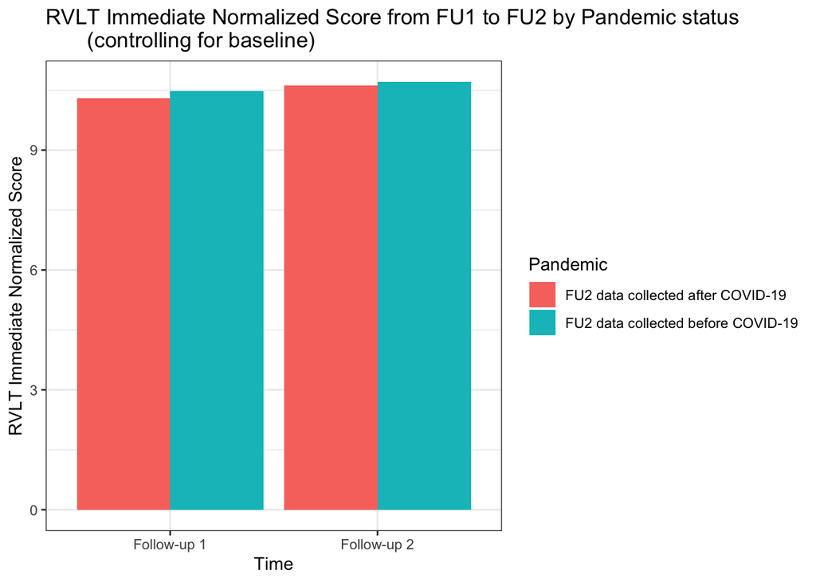

```r
RVLTimmediate_lsmeans_adj10 <- summary(lsmeans(modelRVLT_imm_adj10, ~timefactor|Pandemic))
RVLTimmediate_lsmeans_adj10$Time<-NA
RVLTimmediate_lsmeans_adj10$Time[RVLTimmediate_lsmeans_adj10$timefactor==1]<-"Follow-up 1"
RVLTimmediate_lsmeans_adj10$Time[RVLTimmediate_lsmeans_adj10$timefactor==2]<-"Follow-up 2"
ggplot(RVLTimmediate_lsmeans_adj10, aes(x = Time, y = lsmean, fill = Pandemic)) +
  geom_bar(stat="identity", position=position_dodge()) +
  labs(x = "Time", y = "RVLT Immediate Normalized Score", title = "RVLT Immediate Normalized Score from FU1 to FU2 by Pandemic status
       (controlling for baseline)") +
  theme_bw()
```

### 5.1.4) Planned contrasts

Test whether differences between cohorts at FU1 and FU2 are significant

```r
lsmeans.RVLTImm10 <- lsmeans(modelRVLT_imm_adj10, ~Pandemic|timefactor)
contrast(lsmeans.RVLTImm10,list(c1st),by=NULL)
```

```
##  contrast                                      estimate         SE       df
##  structure(c(-1, 1, 1, -1), dim = c(4L, 1L)) 0.09844167 0.07759502 10134.68
##  t.ratio p.value
##    1.269  0.2046
##
## Results are averaged over the levels of: Sex, Education, Ethnicity, IncomeLevel, SmokingStatus, Relationshipstatus, Livingstatus, Anxiety, MoodDisord
## Degrees-of-freedom method: kenward-roger
```

## 5.2) RVLT Delayed Recall

### 5.2.1) Model

```r
modelRVLT_del_adj10<- lmer(RVLT_Delayed_Normed~ timefactor*Pandemic + Age + Sex + Education + Ethnicity + IncomeLevel + BMI + CESD.10baseline + SmokingStatus + Relationshipstatus +
                            Livingstatus + Anxiety + MoodDisord + Chronicconditions + RVLT_Delayed_Normedbaseline +
                            (1|ID), data= Tracking.data_long_2)
summary(modelRVLT_del_adj10)
```

```
## Linear mixed model fit by REML. t-tests use Satterthwaite's method [
## lmerModLmerTest]
## Formula: RVLT_Delayed_Normed ~ timefactor * Pandemic + Age + Sex + Education +
##     Ethnicity + IncomeLevel + BMI + CESD.10baseline + SmokingStatus +
##     Relationshipstatus + Livingstatus + Anxiety + MoodDisord +
##     Chronicconditions + RVLT_Delayed_Normedbaseline + (1 | ID)
##    Data: Tracking.data_long_2
##
## REML criterion at convergence: 103623.4
##
## Scaled residuals:
##     Min      1Q  Median      3Q     Max
## -3.9202 -0.5513 -0.0366  0.5075  4.1570
##
## Random effects:
##  Groups   Name        Variance Std.Dev.
##  ID       (Intercept) 4.099    2.025
##  Residual             6.955    2.637
## Number of obs: 20030, groups:  ID, 10379
##
## Fixed effects:
##                                                          Estimate Std. Error
## (Intercept)                                             7.308e+00  3.505e-01
## timefactor2                                             5.842e-01  5.580e-02
## PandemicFU2 data collected before COVID-19              2.840e-01  6.748e-02
## Age                                                    -1.378e-02  3.345e-03
## SexM                                                   -4.890e-01  6.101e-02
## EducationHigh School Diploma                            3.149e-01  8.587e-02
## EducationLess than High School Diploma                  3.300e-01  1.192e-01
## EducationSome College                                   2.152e-01  1.071e-01
## EthnicityWhite                                          7.508e-01  1.691e-01
## IncomeLevel>$150k                                       5.890e-01  1.615e-01
## IncomeLevel$100-150k                                    4.381e-01  1.286e-01
## IncomeLevel$20-50k                                      2.284e-01  8.397e-02
## IncomeLevel$50-100k                                     5.421e-01  9.082e-02
## BMI                                                    -1.686e-02  5.563e-03
## CESD.10baseline                                        -2.056e-02  6.818e-03
## SmokingStatusFormer Smoker                              6.218e-02  1.149e-01
## SmokingStatusNever Smoked                               2.801e-01  1.199e-01
## SmokingStatusOccasional Smoker                          1.684e-02  2.345e-01
```

[output cut: 61 more lines]

```
## SmokingStatusOccasional Smoker                         0.942767
## RelationshipstatusMarried                              0.959889
## RelationshipstatusSeparated                            0.487961
## RelationshipstatusSingle                               0.594311
## RelationshipstatusWidowed                              0.095282 .
## LivingstatusAssisted Living                            0.001738 **
## LivingstatusHouse                                      0.150622
## LivingstatusOther                                      0.896827
## AnxietyYes                                             0.483834
## MoodDisordYes                                          0.060177 .
## Chronicconditions                                      0.002203 **
## RVLT_Delayed_Normedbaseline                             < 2e-16 ***
## timefactor2:PandemicFU2 data collected before COVID-19 5.23e-05 ***
## ---
## Signif. codes:  0 '***' 0.001 '**' 0.01 '*' 0.05 '.' 0.1 ' ' 1
```

```
##
## Correlation matrix not shown by default, as p = 30 > 12.
## Use print(x, correlation=TRUE)  or
##     vcov(x)        if you need it
```

```r
anova(modelRVLT_del_adj10)
```

```
## Type III Analysis of Variance Table with Satterthwaite's method
##                              Sum Sq Mean Sq NumDF DenDF   F value    Pr(>F)
## timefactor                    911.8   911.8     1 10061  131.1009 < 2.2e-16 ***
## Pandemic                       37.9    37.9     1 10308    5.4531 0.0195524 *
## Age                           118.1   118.1     1 10342   16.9759 3.815e-05 ***
## Sex                           446.7   446.7     1 10295   64.2369 1.223e-15 ***
## Education                     140.2    46.7     3 10344    6.7190 0.0001589 ***
## Ethnicity                     137.1   137.1     1 10343   19.7076 9.118e-06 ***
## IncomeLevel                   295.0    73.8     4 10284   10.6061 1.417e-08 ***
## BMI                            63.9    63.9     1 10222    9.1877 0.0024425 **
## CESD.10baseline                63.3    63.3     1 10340    9.0991 0.0025636 **
## SmokingStatus                 100.6    33.5     3 10295    4.8210 0.0023486 **
## Relationshipstatus             37.4     9.3     4 10334    1.3435 0.2511201
## Livingstatus                   97.0    32.3     3 10358    4.6502 0.0029853 **
## Anxiety                         3.4     3.4     1 10289    0.4902 0.4838338
## MoodDisord                     24.6    24.6     1 10279    3.5333 0.0601766 .
## Chronicconditions              65.2    65.2     1 10299    9.3769 0.0022030 **
## RVLT_Delayed_Normedbaseline 19251.5 19251.5     1 10292 2768.1443 < 2.2e-16 ***
## timefactor:Pandemic           113.9   113.9     1 10061   16.3755 5.234e-05 ***
## ---
## Signif. codes:  0 '***' 0.001 '**' 0.01 '*' 0.05 '.' 0.1 ' ' 1
```

### 5.2.2) Estimated marginal means

```r
lsmeans(modelRVLT_del_adj10, ~Pandemic|timefactor)
```

```
## timefactor = 1:
##  Pandemic                             lsmean        SE       df lower.CL
##  FU2 data collected after COVID-19  10.37762 0.1800165 10808.72 10.02476
##  FU2 data collected before COVID-19 10.66160 0.1804340 10738.92 10.30792
##  upper.CL
##  10.73049
##  11.01528
##
## timefactor = 2:
##  Pandemic                             lsmean        SE       df lower.CL
##  FU2 data collected after COVID-19  10.96180 0.1802059 10838.82 10.60856
##  FU2 data collected before COVID-19 10.94068 0.1803483 10725.46 10.58717
##  upper.CL
##  11.31503
##  11.29420
##
## Results are averaged over the levels of: Sex, Education, Ethnicity, IncomeLevel, SmokingStatus, Relationshipstatus, Livingstatus, Anxiety, MoodDisord
## Degrees-of-freedom method: kenward-roger
## Confidence level used: 0.95
```

```r
contrast(lsmeans(modelRVLT_del_adj10, ~Pandemic|timefactor), "pairwise", adj="none")
```

```
## timefactor = 1:
##  contrast
##  (FU2 data collected after COVID-19) - (FU2 data collected before COVID-19)
##     estimate         SE       df t.ratio p.value
##  -0.28397783 0.06747662 17616.67  -4.209  <.0001
##
## timefactor = 2:
##  contrast
##  (FU2 data collected after COVID-19) - (FU2 data collected before COVID-19)
##     estimate         SE       df t.ratio p.value
##   0.02111468 0.06800440 17749.18   0.310  0.7562
##
## Results are averaged over the levels of: Sex, Education, Ethnicity, IncomeLevel, SmokingStatus, Relationshipstatus, Livingstatus, Anxiety, MoodDisord
## Degrees-of-freedom method: kenward-roger
```

```r
confint(contrast(lsmeans(modelRVLT_del_adj10, ~Pandemic|timefactor), "pairwise", adj="none"), parm, level = 0.95)
```

```
## timefactor = 1:
##  contrast
##  (FU2 data collected after COVID-19) - (FU2 data collected before COVID-19)
##     estimate         SE       df   lower.CL  upper.CL
##  -0.28397783 0.06747662 17616.67 -0.4162387 -0.151717
##
## timefactor = 2:
##  contrast
##  (FU2 data collected after COVID-19) - (FU2 data collected before COVID-19)
##     estimate         SE       df   lower.CL  upper.CL
##   0.02111468 0.06800440 17749.18 -0.1121806  0.154410
##
## Results are averaged over the levels of: Sex, Education, Ethnicity, IncomeLevel, SmokingStatus, Relationshipstatus, Livingstatus, Anxiety, MoodDisord
## Degrees-of-freedom method: kenward-roger
## Confidence level used: 0.95
```

### 5.2.3) Graph of estimated marginal means

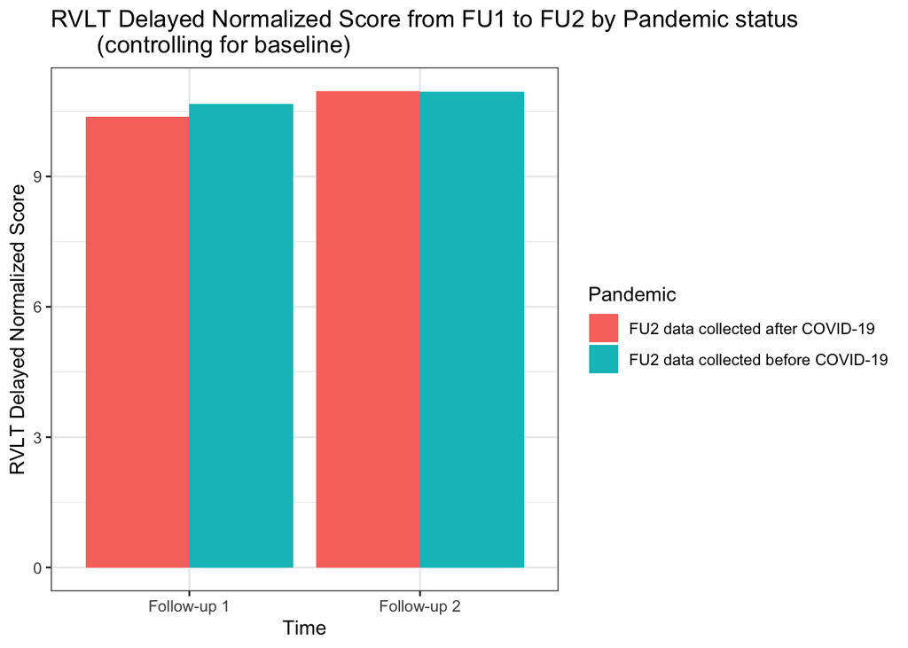

```r
RVLTdelayed_lsmeans_adj10 <- summary(lsmeans(modelRVLT_del_adj10, ~timefactor|Pandemic))
RVLTdelayed_lsmeans_adj10$Time<-NA
RVLTdelayed_lsmeans_adj10$Time[RVLTdelayed_lsmeans_adj10$timefactor==1]<-"Follow-up 1"
RVLTdelayed_lsmeans_adj10$Time[RVLTdelayed_lsmeans_adj10$timefactor==2]<-"Follow-up 2"
ggplot(RVLTdelayed_lsmeans_adj10, aes(x = Time, y = lsmean, fill = Pandemic)) +
  geom_bar(stat="identity", position=position_dodge()) +
  labs(x = "Time", y = "RVLT Delayed Normalized Score", title = "RVLT Delayed Normalized Score from FU1 to FU2 by Pandemic status
       (controlling for baseline)") +
  theme_bw()
```

### 5.2.4) Planned contrasts

Test whether differences between cohorts at FU1 and FU2 are significant

```r
lsmeans.RVLTDel10 <- lsmeans(modelRVLT_del_adj10, ~Pandemic|timefactor)
contrast(lsmeans.RVLTDel10,list(c1st),by=NULL)
```

```
##  contrast                                     estimate         SE      df
##  structure(c(-1, 1, 1, -1), dim = c(4L, 1L)) 0.3050925 0.07539398 10051.4
##  t.ratio p.value
##    4.047  0.0001
##
## Results are averaged over the levels of: Sex, Education, Ethnicity, IncomeLevel, SmokingStatus, Relationshipstatus, Livingstatus, Anxiety, MoodDisord
## Degrees-of-freedom method: kenward-roger
```

## 5.3) Mental Alteration Test

### 5.3.1) Model

```r
modelMAT_adj10<- lmer(MAT_Normed~ timefactor*Pandemic + Age + Sex + Education + Ethnicity + IncomeLevel + BMI + CESD.10baseline + SmokingStatus + Relationshipstatus +
                            Livingstatus + Anxiety + MoodDisord + Chronicconditions + MAT_Normedbaseline +
                      (1|ID), data= Tracking.data_long_2)
summary(modelMAT_adj10)
```

```
## Linear mixed model fit by REML. t-tests use Satterthwaite's method [
## lmerModLmerTest]
## Formula: MAT_Normed ~ timefactor * Pandemic + Age + Sex + Education +
##     Ethnicity + IncomeLevel + BMI + CESD.10baseline + SmokingStatus +
##     Relationshipstatus + Livingstatus + Anxiety + MoodDisord +
##     Chronicconditions + MAT_Normedbaseline + (1 | ID)
##    Data: Tracking.data_long_2
##
## REML criterion at convergence: 98080.7
##
## Scaled residuals:
##     Min      1Q  Median      3Q     Max
## -3.4255 -0.5244 -0.0823  0.3678  4.8694
##
## Random effects:
##  Groups   Name        Variance Std.Dev.
##  ID       (Intercept) 2.322    1.524
##  Residual             8.535    2.921
## Number of obs: 18841, groups:  ID, 10262
##
## Fixed effects:
##                                                          Estimate Std. Error
## (Intercept)                                             7.772e+00  3.383e-01
## timefactor2                                            -1.408e+00  6.399e-02
## PandemicFU2 data collected before COVID-19             -5.110e-01  6.897e-02
## Age                                                    -1.182e-02  3.216e-03
## SexM                                                   -1.185e+00  5.842e-02
## EducationHigh School Diploma                           -4.450e-03  8.238e-02
## EducationLess than High School Diploma                 -1.563e-01  1.158e-01
## EducationSome College                                  -1.551e-01  1.021e-01
## EthnicityWhite                                          9.209e-01  1.630e-01
## IncomeLevel>$150k                                       1.290e-01  1.546e-01
## IncomeLevel$100-150k                                    1.601e-01  1.233e-01
## IncomeLevel$20-50k                                      1.050e-01  8.082e-02
## IncomeLevel$50-100k                                     1.458e-01  8.740e-02
## BMI                                                    -1.546e-02  5.326e-03
## CESD.10baseline                                        -1.402e-02  6.537e-03
## SmokingStatusFormer Smoker                              5.973e-02  1.099e-01
## SmokingStatusNever Smoked                              -6.673e-02  1.147e-01
## SmokingStatusOccasional Smoker                          1.143e-01  2.245e-01
```

[output cut: 61 more lines]

```
## SmokingStatusOccasional Smoker                          0.61064
## RelationshipstatusMarried                               0.70883
## RelationshipstatusSeparated                             0.70247
## RelationshipstatusSingle                               9.30e-05 ***
## RelationshipstatusWidowed                               0.73194
## LivingstatusAssisted Living                             0.54416
## LivingstatusHouse                                       0.01576 *
## LivingstatusOther                                       0.01720 *
## AnxietyYes                                              0.21912
## MoodDisordYes                                           0.90398
## Chronicconditions                                       0.00138 **
## MAT_Normedbaseline                                      < 2e-16 ***
## timefactor2:PandemicFU2 data collected before COVID-19 5.86e-10 ***
## ---
## Signif. codes:  0 '***' 0.001 '**' 0.01 '*' 0.05 '.' 0.1 ' ' 1
```

```
##
## Correlation matrix not shown by default, as p = 30 > 12.
## Use print(x, correlation=TRUE)  or
##     vcov(x)        if you need it
```

```r
anova(modelMAT_adj10)
```

```
## Type III Analysis of Variance Table with Satterthwaite's method
##                      Sum Sq Mean Sq NumDF   DenDF   F value    Pr(>F)
## timefactor           5944.5  5944.5     1  9651.9  696.5100 < 2.2e-16 ***
## Pandemic              173.1   173.1     1 10008.1   20.2828 6.756e-06 ***
## Age                   115.2   115.2     1 10143.2   13.4993 0.0002399 ***
## Sex                  3510.3  3510.3     1  9967.0  411.2965 < 2.2e-16 ***
## Education              32.6    10.9     3 10020.4    1.2743 0.2813077
## Ethnicity             272.4   272.4     1 10144.8   31.9206 1.649e-08 ***
## IncomeLevel            25.6     6.4     4  9942.1    0.7487 0.5587154
## BMI                    71.9    71.9     1  9815.8    8.4241 0.0037111 **
## CESD.10baseline        39.2    39.2     1  9939.1    4.5976 0.0320405 *
## SmokingStatus          42.1    14.0     3  9915.8    1.6430 0.1771420
## Relationshipstatus    209.5    52.4     4 10036.3    6.1367 6.285e-05 ***
## Livingstatus           79.6    26.5     3 10020.5    3.1078 0.0253301 *
## Anxiety                12.9    12.9     1  9972.2    1.5103 0.2191165
## MoodDisord              0.1     0.1     1  9905.2    0.0146 0.9039759
## Chronicconditions      87.4    87.4     1 10079.5   10.2442 0.0013754 **
## MAT_Normedbaseline  27855.4 27855.4     1 10042.1 3263.8035 < 2.2e-16 ***
## timefactor:Pandemic   328.1   328.1     1  9652.6   38.4475 5.855e-10 ***
## ---
## Signif. codes:  0 '***' 0.001 '**' 0.01 '*' 0.05 '.' 0.1 ' ' 1
```

### 5.3.2) Estimated marginal means

```r
lsmeans(modelMAT_adj10, ~Pandemic|timefactor)
```

```
## timefactor = 1:
##  Pandemic                              lsmean        SE       df  lower.CL
##  FU2 data collected after COVID-19  10.665980 0.1741807 10709.43 10.324554
##  FU2 data collected before COVID-19 10.154966 0.1742890 10591.05  9.813327
##   upper.CL
##  11.007407
##  10.496605
##
## timefactor = 2:
##  Pandemic                              lsmean        SE       df  lower.CL
##  FU2 data collected after COVID-19   9.258314 0.1740161 10687.80  8.917210
##  FU2 data collected before COVID-19  9.282878 0.1741834 10577.03  8.941446
##   upper.CL
##   9.599418
##   9.624310
##
## Results are averaged over the levels of: Sex, Education, Ethnicity, IncomeLevel, SmokingStatus, Relationshipstatus, Livingstatus, Anxiety, MoodDisord
## Degrees-of-freedom method: kenward-roger
## Confidence level used: 0.95
```

```r
contrast(lsmeans(modelMAT_adj10, ~Pandemic|timefactor), "pairwise", adj="none")
```

```
## timefactor = 1:
##  contrast
##  (FU2 data collected after COVID-19) - (FU2 data collected before COVID-19)
##    estimate         SE       df t.ratio p.value
##   0.5110145 0.06896917 18128.64   7.409  <.0001
##
## timefactor = 2:
##  contrast
##  (FU2 data collected after COVID-19) - (FU2 data collected before COVID-19)
##    estimate         SE       df t.ratio p.value
##  -0.0245641 0.06933355 18159.72  -0.354  0.7231
##
## Results are averaged over the levels of: Sex, Education, Ethnicity, IncomeLevel, SmokingStatus, Relationshipstatus, Livingstatus, Anxiety, MoodDisord
## Degrees-of-freedom method: kenward-roger
```

```r
confint(contrast(lsmeans(modelMAT_adj10, ~Pandemic|timefactor), "pairwise", adj="none"), parm, level = 0.95)
```

```
## timefactor = 1:
##  contrast
##  (FU2 data collected after COVID-19) - (FU2 data collected before COVID-19)
##    estimate         SE       df   lower.CL  upper.CL
##   0.5110145 0.06896917 18128.64  0.3758284 0.6462006
##
## timefactor = 2:
##  contrast
##  (FU2 data collected after COVID-19) - (FU2 data collected before COVID-19)
##    estimate         SE       df   lower.CL  upper.CL
##  -0.0245641 0.06933355 18159.72 -0.1604644 0.1113362
##
## Results are averaged over the levels of: Sex, Education, Ethnicity, IncomeLevel, SmokingStatus, Relationshipstatus, Livingstatus, Anxiety, MoodDisord
## Degrees-of-freedom method: kenward-roger
## Confidence level used: 0.95
```

### 5.3.3) Graph of estimated marginal means

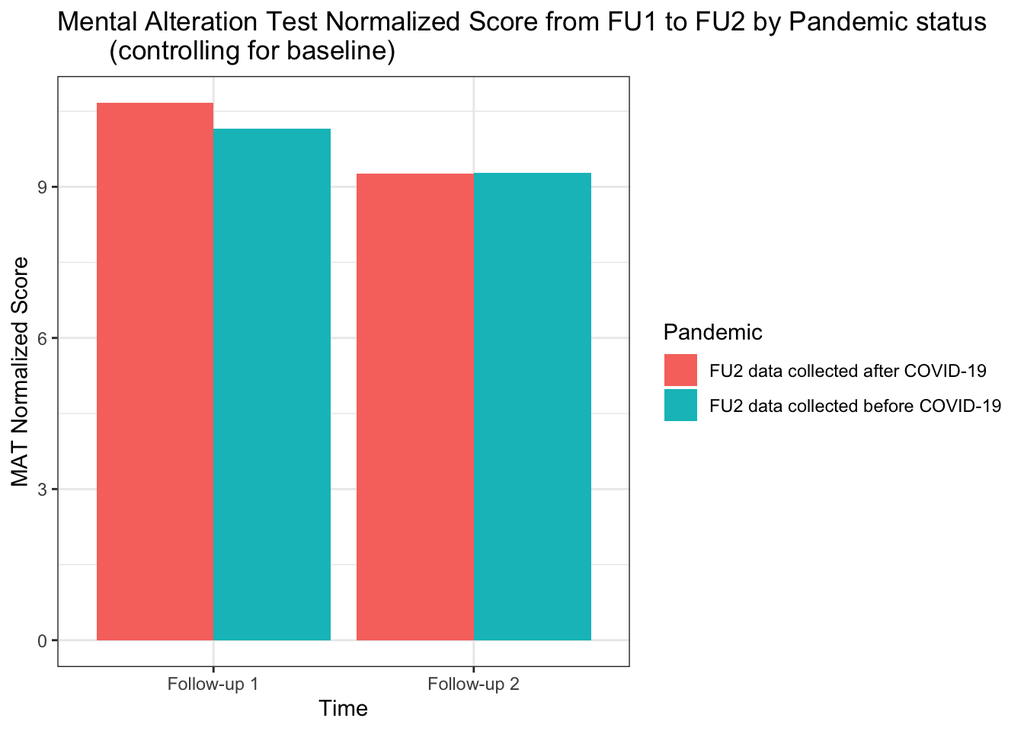

```r
MAT_lsmeans_adj10 <- summary(lsmeans(modelMAT_adj10, ~Pandemic|timefactor))
MAT_lsmeans_adj10$Time<-NA
MAT_lsmeans_adj10$Time[MAT_lsmeans_adj10$timefactor==1]<-"Follow-up 1"
MAT_lsmeans_adj10$Time[MAT_lsmeans_adj10$timefactor==2]<-"Follow-up 2"
ggplot(MAT_lsmeans_adj10, aes(x = Time, y = lsmean, fill = Pandemic)) +
  geom_bar(stat="identity", position=position_dodge()) +
  labs(x = "Time", y = "MAT Normalized Score", title = "Mental Alteration Test Normalized Score from FU1 to FU2 by Pandemic status
       (controlling for baseline)") +
  theme_bw()
```

### 5.3.4) Planned contrasts

Test whether differences between cohorts at FU1 and FU2 are significant

```r
lsmeans.MAT10 <- lsmeans(modelMAT_adj10, ~Pandemic|timefactor)
contrast(lsmeans.MAT10,list(c1st),by=NULL)
```

```
##  contrast                                      estimate        SE      df
##  structure(c(-1, 1, 1, -1), dim = c(4L, 1L)) -0.5355786 0.0863762 9673.68
##  t.ratio p.value
##   -6.201  <.0001
##
## Results are averaged over the levels of: Sex, Education, Ethnicity, IncomeLevel, SmokingStatus, Relationshipstatus, Livingstatus, Anxiety, MoodDisord
## Degrees-of-freedom method: kenward-roger
```

## 5.4) Animal Fluency

### 5.4.1) Model

```r
modelAnimals_adj10<- lmer(Animal_Fluency_Normed ~ timefactor*Pandemic + Age + Sex + Education + Ethnicity + IncomeLevel + BMI + CESD.10baseline + SmokingStatus + Relationshipstatus +
                            Livingstatus + Anxiety + MoodDisord + Chronicconditions + Animal_Fluency_Normedbaseline +
                           (1|ID), data= Tracking.data_long_2)
summary(modelAnimals_adj10)
```

```
## Linear mixed model fit by REML. t-tests use Satterthwaite's method [
## lmerModLmerTest]
## Formula:
## Animal_Fluency_Normed ~ timefactor * Pandemic + Age + Sex + Education +
##     Ethnicity + IncomeLevel + BMI + CESD.10baseline + SmokingStatus +
##     Relationshipstatus + Livingstatus + Anxiety + MoodDisord +
##     Chronicconditions + Animal_Fluency_Normedbaseline + (1 |      ID)
##    Data: Tracking.data_long_2
##
## REML criterion at convergence: 94871.6
##
## Scaled residuals:
##     Min      1Q  Median      3Q     Max
## -3.8664 -0.5429 -0.0218  0.5261  4.5657
##
## Random effects:
##  Groups   Name        Variance Std.Dev.
##  ID       (Intercept) 2.996    1.731
##  Residual             3.870    1.967
## Number of obs: 20333, groups:  ID, 10403
##
## Fixed effects:
##                                                          Estimate Std. Error
## (Intercept)                                             5.746e+00  2.835e-01
## timefactor2                                             5.077e-02  4.127e-02
## PandemicFU2 data collected before COVID-19              1.944e-01  5.280e-02
## Age                                                    -2.582e-02  2.665e-03
## SexM                                                   -9.745e-02  4.884e-02
## EducationHigh School Diploma                            2.223e-01  6.891e-02
## EducationLess than High School Diploma                  7.748e-02  9.497e-02
## EducationSome College                                   2.309e-01  8.596e-02
## EthnicityWhite                                          6.059e-01  1.353e-01
## IncomeLevel>$150k                                       1.162e-01  1.295e-01
## IncomeLevel$100-150k                                    1.947e-01  1.032e-01
## IncomeLevel$20-50k                                     -1.037e-02  6.726e-02
## IncomeLevel$50-100k                                     1.725e-01  7.282e-02
## BMI                                                    -5.115e-03  4.466e-03
## CESD.10baseline                                        -1.453e-02  5.471e-03
## SmokingStatusFormer Smoker                              1.002e-01  9.210e-02
## SmokingStatusNever Smoked                               8.221e-02  9.613e-02
```

[output cut: 62 more lines]

```
## SmokingStatusOccasional Smoker                         0.728827
## RelationshipstatusMarried                              0.371739
## RelationshipstatusSeparated                            0.092828 .
## RelationshipstatusSingle                               0.635404
## RelationshipstatusWidowed                              0.838382
## LivingstatusAssisted Living                            0.896701
## LivingstatusHouse                                      0.004464 **
## LivingstatusOther                                      0.844262
## AnxietyYes                                             0.718279
## MoodDisordYes                                          0.177633
## Chronicconditions                                      0.071161 .
## Animal_Fluency_Normedbaseline                           < 2e-16 ***
## timefactor2:PandemicFU2 data collected before COVID-19 0.870926
## ---
## Signif. codes:  0 '***' 0.001 '**' 0.01 '*' 0.05 '.' 0.1 ' ' 1
```

```
##
## Correlation matrix not shown by default, as p = 30 > 12.
## Use print(x, correlation=TRUE)  or
##     vcov(x)        if you need it
```

```r
anova(modelAnimals_adj10)
```

```
## Type III Analysis of Variance Table with Satterthwaite's method
##                                Sum Sq Mean Sq NumDF DenDF   F value    Pr(>F)
## timefactor                       15.2    15.2     1 10153    3.9375  0.047247
## Pandemic                         75.3    75.3     1 10337   19.4654 1.035e-05
## Age                             363.2   363.2     1 10332   93.8618 < 2.2e-16
## Sex                              15.4    15.4     1 10316    3.9817  0.046025
## Education                        60.2    20.1     3 10349    5.1889  0.001398
## Ethnicity                        77.5    77.5     1 10293   20.0379 7.674e-06
## IncomeLevel                      53.8    13.5     4 10317    3.4779  0.007609
## BMI                               5.1     5.1     1 10277    1.3118  0.252095
## CESD.10baseline                  27.3    27.3     1 10355    7.0542  0.007920
## SmokingStatus                     7.8     2.6     3 10321    0.6677  0.571781
## Relationshipstatus               12.1     3.0     4 10348    0.7840  0.535339
## Livingstatus                     34.9    11.6     3 10269    3.0091  0.028977
## Anxiety                           0.5     0.5     1 10338    0.1302  0.718279
## MoodDisord                        7.0     7.0     1 10340    1.8176  0.177633
## Chronicconditions                12.6    12.6     1 10303    3.2567  0.071161
## Animal_Fluency_Normedbaseline 28800.0 28800.0     1 10311 7442.0627 < 2.2e-16
## timefactor:Pandemic               0.1     0.1     1 10153    0.0264  0.870926
##
## timefactor                    *
## Pandemic                      ***
## Age                           ***
## Sex                           *
## Education                     **
## Ethnicity                     ***
## IncomeLevel                   **
## BMI
## CESD.10baseline               **
## SmokingStatus
## Relationshipstatus
## Livingstatus                  *
## Anxiety
## MoodDisord
## Chronicconditions             .
## Animal_Fluency_Normedbaseline ***
## timefactor:Pandemic
## ---
## Signif. codes:  0 '***' 0.001 '**' 0.01 '*' 0.05 '.' 0.1 ' ' 1
```

### 5.4.2) Estimated marginal means

```r
lsmeans(modelAnimals_adj10, ~Pandemic|timefactor)
```

```
## timefactor = 1:
##  Pandemic                             lsmean        SE       df lower.CL
##  FU2 data collected after COVID-19  10.84939 0.1438453 10712.42 10.56743
##  FU2 data collected before COVID-19 11.04381 0.1441413 10644.83 10.76127
##  upper.CL
##  11.13136
##  11.32636
##
## timefactor = 2:
##  Pandemic                             lsmean        SE       df lower.CL
##  FU2 data collected after COVID-19  10.90016 0.1439582 10735.89 10.61797
##  FU2 data collected before COVID-19 11.10364 0.1441642 10649.60 10.82105
##  upper.CL
##  11.18234
##  11.38623
##
## Results are averaged over the levels of: Sex, Education, Ethnicity, IncomeLevel, SmokingStatus, Relationshipstatus, Livingstatus, Anxiety, MoodDisord
## Degrees-of-freedom method: kenward-roger
## Confidence level used: 0.95
```

```r
contrast(lsmeans(modelAnimals_adj10, ~Pandemic|timefactor), "pairwise", adj="none")
```

```
## timefactor = 1:
##  contrast
##  (FU2 data collected after COVID-19) - (FU2 data collected before COVID-19)
##    estimate         SE       df t.ratio p.value
##  -0.1944217 0.05280075 17004.38  -3.682  0.0002
##
## timefactor = 2:
##  contrast
##  (FU2 data collected after COVID-19) - (FU2 data collected before COVID-19)
##    estimate         SE       df t.ratio p.value
##  -0.2034773 0.05321545 17176.59  -3.824  0.0001
##
## Results are averaged over the levels of: Sex, Education, Ethnicity, IncomeLevel, SmokingStatus, Relationshipstatus, Livingstatus, Anxiety, MoodDisord
## Degrees-of-freedom method: kenward-roger
```

```r
confint(contrast(lsmeans(modelAnimals_adj10, ~Pandemic|timefactor), "pairwise", adj="none"), parm, level = 0.95)
```

```
## timefactor = 1:
##  contrast
##  (FU2 data collected after COVID-19) - (FU2 data collected before COVID-19)
##    estimate         SE       df   lower.CL    upper.CL
##  -0.1944217 0.05280075 17004.38 -0.2979167 -0.09092677
##
## timefactor = 2:
##  contrast
##  (FU2 data collected after COVID-19) - (FU2 data collected before COVID-19)
##    estimate         SE       df   lower.CL    upper.CL
##  -0.2034773 0.05321545 17176.59 -0.3077850 -0.09916961
##
## Results are averaged over the levels of: Sex, Education, Ethnicity, IncomeLevel, SmokingStatus, Relationshipstatus, Livingstatus, Anxiety, MoodDisord
## Degrees-of-freedom method: kenward-roger
## Confidence level used: 0.95
```

### 5.4.3) Graph of estimated marginal means

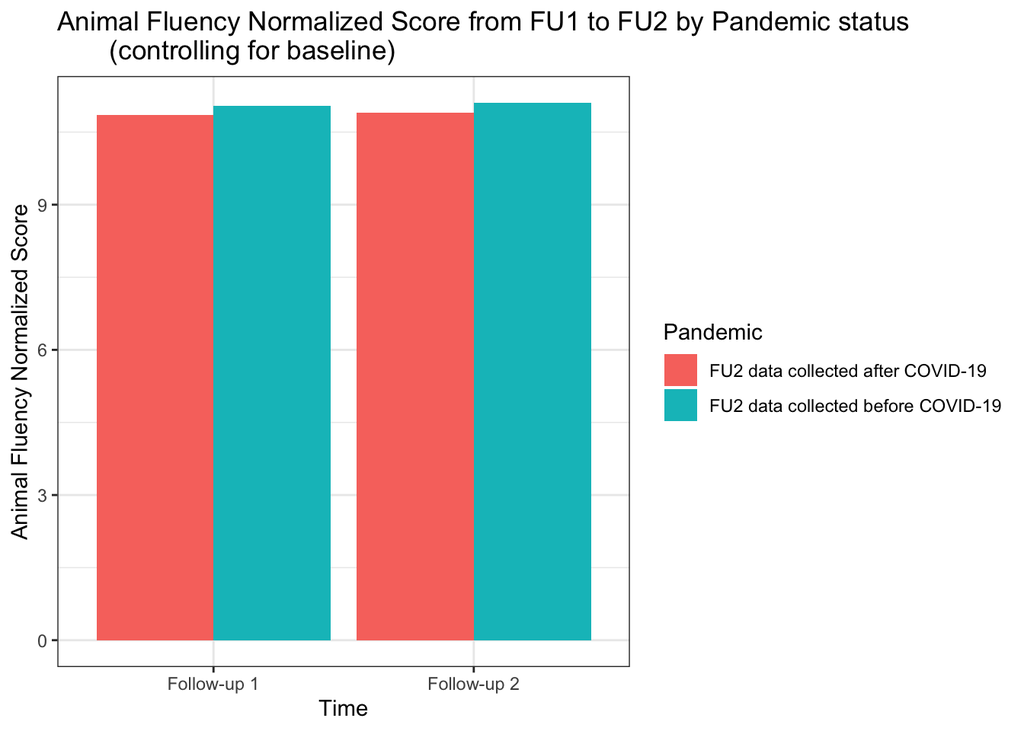

```r
Animals_lsmeans_adj10 <- summary(lsmeans(modelAnimals_adj10, ~timefactor|Pandemic))
Animals_lsmeans_adj10$Time<-NA
Animals_lsmeans_adj10$Time[Animals_lsmeans_adj10$timefactor==1]<-"Follow-up 1"
Animals_lsmeans_adj10$Time[Animals_lsmeans_adj10$timefactor==2]<-"Follow-up 2"
ggplot(Animals_lsmeans_adj10, aes(x = Time, y = lsmean, fill = Pandemic)) +
  geom_bar(stat="identity", position=position_dodge()) +
  labs(x = "Time", y = "Animal Fluency Normalized Score", title = "Animal Fluency Normalized Score from FU1 to FU2 by Pandemic status
       (controlling for baseline)") +
  theme_bw()
```

### 5.4.4) Planned contrasts

Test whether differences between cohorts at FU1 and FU2 are significant

```r
lsmeans.Animals10 <- lsmeans(modelAnimals_adj10, ~Pandemic|timefactor)
contrast(lsmeans.Animals10,list(c1st),by=NULL)
```

```
##  contrast                                        estimate         SE       df
##  structure(c(-1, 1, 1, -1), dim = c(4L, 1L)) -0.009055605 0.05573164 10171.64
##  t.ratio p.value
##   -0.162  0.8709
##
## Results are averaged over the levels of: Sex, Education, Ethnicity, IncomeLevel, SmokingStatus, Relationshipstatus, Livingstatus, Anxiety, MoodDisord
## Degrees-of-freedom method: kenward-roger
```

# 6) Age and Sex Interaction Model

Age and Sex grouping

```r
Tracking.data_long_2$Age_sex<-NA
Tracking.data_long_2$Age_sex[Tracking.data_long_2$Age<=64 & Tracking.data_long_2$Sex == "M"]<-"Males 45-64"
Tracking.data_long_2$Age_sex[Tracking.data_long_2$Age<=64 & Tracking.data_long_2$Sex == "F"]<-"Females 45-64"
Tracking.data_long_2$Age_sex[Tracking.data_long_2$Age>64 & Tracking.data_long_2$Sex == "M"]<-"Males 65+"
Tracking.data_long_2$Age_sex[Tracking.data_long_2$Age>64 & Tracking.data_long_2$Sex == "F"]<-"Females 65+"
```

## 6.1) RVLT Immediate Recall

### 6.1.1) Model

```r
modelRVLT_imm_adj11<- lmer(RVLT_Immediate_Normed~ timefactor*Pandemic*Age_sex + Education + Ethnicity + IncomeLevel + BMI + CESD.10baseline + SmokingStatus + Relationshipstatus +
                            Livingstatus + Anxiety + MoodDisord + Chronicconditions + RVLT_Immediate_Normedbaseline +
                            (1|ID), data= Tracking.data_long_2)
summary(modelRVLT_imm_adj11)
```

```
## Linear mixed model fit by REML. t-tests use Satterthwaite's method [
## lmerModLmerTest]
## Formula: RVLT_Immediate_Normed ~ timefactor * Pandemic * Age_sex + Education +
##     Ethnicity + IncomeLevel + BMI + CESD.10baseline + SmokingStatus +
##     Relationshipstatus + Livingstatus + Anxiety + MoodDisord +
##     Chronicconditions + RVLT_Immediate_Normedbaseline + (1 |      ID)
##    Data: Tracking.data_long_2
##
## REML criterion at convergence: 105586.5
##
## Scaled residuals:
##     Min      1Q  Median      3Q     Max
## -3.6554 -0.5650 -0.0389  0.5308  3.8582
##
## Random effects:
##  Groups   Name        Variance Std.Dev.
##  ID       (Intercept) 4.190    2.047
##  Residual             7.424    2.725
## Number of obs: 20202, groups:  ID, 10396
##
## Fixed effects:
##                                                                             Estimate
## (Intercept)                                                                6.940e+00
## timefactor2                                                                4.514e-01
## PandemicFU2 data collected before COVID-19                                 8.727e-02
## Age_sexFemales 65+                                                        -1.939e-01
## Age_sexMales 45-64                                                        -6.674e-01
## Age_sexMales 65+                                                          -7.695e-01
## EducationHigh School Diploma                                               2.237e-01
## EducationLess than High School Diploma                                     4.888e-01
## EducationSome College                                                      1.600e-01
## EthnicityWhite                                                             6.292e-01
## IncomeLevel>$150k                                                          7.530e-01
## IncomeLevel$100-150k                                                       6.232e-01
## IncomeLevel$20-50k                                                         2.323e-01
## IncomeLevel$50-100k                                                        5.584e-01
## BMI                                                                       -1.449e-02
## CESD.10baseline                                                           -1.887e-02
## SmokingStatusFormer Smoker                                                 4.244e-02
## SmokingStatusNever Smoked                                                  1.996e-01
```

[output cut: 214 more lines]

```
## MoodDisordYes
## Chronicconditions                                                         **
## RVLT_Immediate_Normedbaseline                                             ***
## timefactor2:PandemicFU2 data collected before COVID-19
## timefactor2:Age_sexFemales 65+                                            ***
## timefactor2:Age_sexMales 45-64
## timefactor2:Age_sexMales 65+                                              **
## PandemicFU2 data collected before COVID-19:Age_sexFemales 65+
## PandemicFU2 data collected before COVID-19:Age_sexMales 45-64
## PandemicFU2 data collected before COVID-19:Age_sexMales 65+
## timefactor2:PandemicFU2 data collected before COVID-19:Age_sexFemales 65+
## timefactor2:PandemicFU2 data collected before COVID-19:Age_sexMales 45-64
## timefactor2:PandemicFU2 data collected before COVID-19:Age_sexMales 65+   .
## ---
## Signif. codes:  0 '***' 0.001 '**' 0.01 '*' 0.05 '.' 0.1 ' ' 1
```

```
##
## Correlation matrix not shown by default, as p = 40 > 12.
## Use print(x, correlation=TRUE)  or
##     vcov(x)        if you need it
```

```r
anova(modelRVLT_imm_adj11)
```

```
## Type III Analysis of Variance Table with Satterthwaite's method
##                                Sum Sq Mean Sq NumDF DenDF   F value    Pr(>F)
## timefactor                      169.6   169.6     1 10155   22.8434 1.782e-06
## Pandemic                         41.8    41.8     1 10343    5.6243 0.0177313
## Age_sex                         946.4   315.5     3 10342   42.4950 < 2.2e-16
## Education                       154.2    51.4     3 10334    6.9225 0.0001188
## Ethnicity                        99.9    99.9     1 10254   13.4582 0.0002452
## IncomeLevel                     385.1    96.3     4 10289   12.9675 1.560e-10
## BMI                              48.6    48.6     1 10256    6.5493 0.0105070
## CESD.10baseline                  55.1    55.1     1 10317    7.4160 0.0064754
## SmokingStatus                    59.5    19.8     3 10297    2.6732 0.0456627
## Relationshipstatus              119.1    29.8     4 10350    4.0096 0.0029827
## Livingstatus                     82.7    27.6     3 10273    3.7143 0.0110062
## Anxiety                           0.1     0.1     1 10310    0.0139 0.9059882
## MoodDisord                       16.7    16.7     1 10304    2.2441 0.1341517
## Chronicconditions                64.4    64.4     1 10319    8.6691 0.0032437
## RVLT_Immediate_Normedbaseline 16208.4 16208.4     1 10321 2183.2965 < 2.2e-16
## timefactor:Pandemic               0.0     0.0     1 10155    0.0023 0.9618127
## timefactor:Age_sex              346.5   115.5     3 10146   15.5582 4.290e-10
## Pandemic:Age_sex                 27.1     9.0     3 10338    1.2164 0.3019797
## timefactor:Pandemic:Age_sex      25.5     8.5     3 10146    1.1449 0.3293676
##
## timefactor                    ***
## Pandemic                      *
## Age_sex                       ***
## Education                     ***
## Ethnicity                     ***
## IncomeLevel                   ***
## BMI                           *
## CESD.10baseline               **
## SmokingStatus                 *
## Relationshipstatus            **
## Livingstatus                  *
## Anxiety
## MoodDisord
## Chronicconditions             **
## RVLT_Immediate_Normedbaseline ***
## timefactor:Pandemic
## timefactor:Age_sex            ***
## Pandemic:Age_sex
## timefactor:Pandemic:Age_sex
## ---
## Signif. codes:  0 '***' 0.001 '**' 0.01 '*' 0.05 '.' 0.1 ' ' 1
```

### 6.1.2) Estimated marginal means

Significantly lower RVLT immediate for males 65+

```r
lsmeans(modelRVLT_imm_adj11, ~Pandemic|timefactor|Age_sex)
```

```
## timefactor = 1, Age_sex = Females 45-64:
##  Pandemic                              lsmean        SE       df  lower.CL
##  FU2 data collected after COVID-19  10.707067 0.2004231 11780.92 10.314204
##  FU2 data collected before COVID-19 10.794333 0.1938650 11311.37 10.414323
##  upper.CL
##  11.09993
##  11.17434
##
## timefactor = 2, Age_sex = Females 45-64:
##  Pandemic                              lsmean        SE       df  lower.CL
##  FU2 data collected after COVID-19  11.158480 0.2010575 11870.42 10.764375
##  FU2 data collected before COVID-19 11.101445 0.1938384 11307.39 10.721489
##  upper.CL
##  11.55259
##  11.48140
##
## timefactor = 1, Age_sex = Females 65+:
##  Pandemic                              lsmean        SE       df  lower.CL
##  FU2 data collected after COVID-19  10.513168 0.2202030 12710.13 10.081537
##  FU2 data collected before COVID-19 10.821400 0.2078429 11986.07 10.413994
##  upper.CL
##  10.94480
##  11.22881
##
## timefactor = 2, Age_sex = Females 65+:
##  Pandemic                              lsmean        SE       df  lower.CL
##  FU2 data collected after COVID-19  10.342444 0.2217520 12905.48  9.907777
##  FU2 data collected before COVID-19 10.608615 0.2078874 11992.17 10.201122
##  upper.CL
##  10.77711
##  11.01611
##
## timefactor = 1, Age_sex = Males 45-64:
##  Pandemic                              lsmean        SE       df  lower.CL
##  FU2 data collected after COVID-19  10.039686 0.1925409 11407.67  9.662273
##  FU2 data collected before COVID-19 10.122698 0.2008412 11818.30  9.729016
##  upper.CL
##  10.41710
##  10.51638
##
```

[output cut: 12 more lines]

```
##  upper.CL
##  10.36959
##  10.42725
##
## timefactor = 2, Age_sex = Males 65+:
##  Pandemic                              lsmean        SE       df  lower.CL
##  FU2 data collected after COVID-19   9.860365 0.2221716 12819.42  9.424876
##  FU2 data collected before COVID-19 10.217875 0.2075553 12074.17  9.811033
##  upper.CL
##  10.29585
##  10.62472
##
## Results are averaged over the levels of: Education, Ethnicity, IncomeLevel, SmokingStatus, Relationshipstatus, Livingstatus, Anxiety, MoodDisord
## Degrees-of-freedom method: kenward-roger
## Confidence level used: 0.95
```

```r
contrast(lsmeans(modelRVLT_imm_adj11, ~Pandemic|timefactor|Age_sex), "pairwise", adj="none")
```

```
## timefactor = 1, Age_sex = Females 45-64:
##  contrast
##  (FU2 data collected after COVID-19) - (FU2 data collected before COVID-19)
##    estimate        SE       df t.ratio p.value
##  -0.0872661 0.1201007 17983.01  -0.727  0.4675
##
## timefactor = 2, Age_sex = Females 45-64:
##  contrast
##  (FU2 data collected after COVID-19) - (FU2 data collected before COVID-19)
##    estimate        SE       df t.ratio p.value
##   0.0570350 0.1213607 18147.63   0.470  0.6384
##
## timefactor = 1, Age_sex = Females 65+:
##  contrast
##  (FU2 data collected after COVID-19) - (FU2 data collected before COVID-19)
##    estimate        SE       df t.ratio p.value
##  -0.3082322 0.1647136 17973.79  -1.871  0.0613
##
## timefactor = 2, Age_sex = Females 65+:
##  contrast
##  (FU2 data collected after COVID-19) - (FU2 data collected before COVID-19)
##    estimate        SE       df t.ratio p.value
##  -0.2661712 0.1670098 18191.34  -1.594  0.1110
##
## timefactor = 1, Age_sex = Males 45-64:
##  contrast
##  (FU2 data collected after COVID-19) - (FU2 data collected before COVID-19)
##    estimate        SE       df t.ratio p.value
##  -0.0830116 0.1228335 18004.38  -0.676  0.4992
##
## timefactor = 2, Age_sex = Males 45-64:
##  contrast
##  (FU2 data collected after COVID-19) - (FU2 data collected before COVID-19)
##    estimate        SE       df t.ratio p.value
##  -0.0101808 0.1230316 18030.11  -0.083  0.9341
##
## timefactor = 1, Age_sex = Males 65+:
##  contrast
##  (FU2 data collected after COVID-19) - (FU2 data collected before COVID-19)
##    estimate        SE       df t.ratio p.value
##  -0.0825158 0.1635775 18041.98  -0.504  0.6140
##
## timefactor = 2, Age_sex = Males 65+:
##  contrast
##  (FU2 data collected after COVID-19) - (FU2 data collected before COVID-19)
##    estimate        SE       df t.ratio p.value
##  -0.3575100 0.1656631 18238.08  -2.158  0.0309
##
## Results are averaged over the levels of: Education, Ethnicity, IncomeLevel, SmokingStatus, Relationshipstatus, Livingstatus, Anxiety, MoodDisord
## Degrees-of-freedom method: kenward-roger
```

```r
confint(contrast(lsmeans(modelRVLT_imm_adj11, ~Pandemic|timefactor|Age_sex), "pairwise", adj="none"), parm, level = 0.95)
```

```
## timefactor = 1, Age_sex = Females 45-64:
##  contrast
##  (FU2 data collected after COVID-19) - (FU2 data collected before COVID-19)
##    estimate        SE       df   lower.CL    upper.CL
##  -0.0872661 0.1201007 17983.01 -0.3226749  0.14814283
##
## timefactor = 2, Age_sex = Females 45-64:
##  contrast
##  (FU2 data collected after COVID-19) - (FU2 data collected before COVID-19)
##    estimate        SE       df   lower.CL    upper.CL
##   0.0570350 0.1213607 18147.63 -0.1808435  0.29491356
##
## timefactor = 1, Age_sex = Females 65+:
##  contrast
##  (FU2 data collected after COVID-19) - (FU2 data collected before COVID-19)
##    estimate        SE       df   lower.CL    upper.CL
##  -0.3082322 0.1647136 17973.79 -0.6310867  0.01462228
##
## timefactor = 2, Age_sex = Females 65+:
##  contrast
##  (FU2 data collected after COVID-19) - (FU2 data collected before COVID-19)
##    estimate        SE       df   lower.CL    upper.CL
##  -0.2661712 0.1670098 18191.34 -0.5935262  0.06118384
##
## timefactor = 1, Age_sex = Males 45-64:
##  contrast
##  (FU2 data collected after COVID-19) - (FU2 data collected before COVID-19)
##    estimate        SE       df   lower.CL    upper.CL
##  -0.0830116 0.1228335 18004.38 -0.3237770  0.15775381
##
## timefactor = 2, Age_sex = Males 45-64:
##  contrast
##  (FU2 data collected after COVID-19) - (FU2 data collected before COVID-19)
##    estimate        SE       df   lower.CL    upper.CL
##  -0.0101808 0.1230316 18030.11 -0.2513345  0.23097289
##
## timefactor = 1, Age_sex = Males 65+:
##  contrast
##  (FU2 data collected after COVID-19) - (FU2 data collected before COVID-19)
##    estimate        SE       df   lower.CL    upper.CL
##  -0.0825158 0.1635775 18041.98 -0.4031434  0.23811169
##
## timefactor = 2, Age_sex = Males 65+:
##  contrast
##  (FU2 data collected after COVID-19) - (FU2 data collected before COVID-19)
##    estimate        SE       df   lower.CL    upper.CL
##  -0.3575100 0.1656631 18238.08 -0.6822254 -0.03279466
##
## Results are averaged over the levels of: Education, Ethnicity, IncomeLevel, SmokingStatus, Relationshipstatus, Livingstatus, Anxiety, MoodDisord
## Degrees-of-freedom method: kenward-roger
## Confidence level used: 0.95
```

### 6.1.3) Graph of estimated marginal means

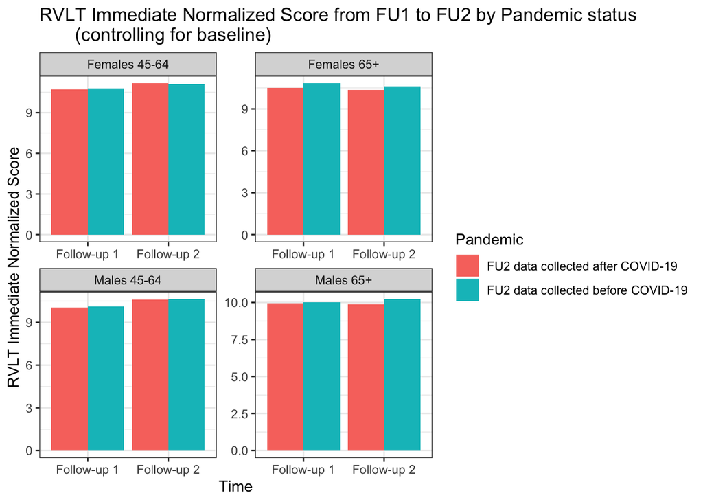

```r
RVLTimmediate_lsmeans_adj11 <- summary(lsmeans(modelRVLT_imm_adj11, ~timefactor|Pandemic|Age_sex))
RVLTimmediate_lsmeans_adj11$Time<-NA
RVLTimmediate_lsmeans_adj11$Time[RVLTimmediate_lsmeans_adj11$timefactor==1]<-"Follow-up 1"
RVLTimmediate_lsmeans_adj11$Time[RVLTimmediate_lsmeans_adj11$timefactor==2]<-"Follow-up 2"
ggplot(RVLTimmediate_lsmeans_adj11, aes(x = Time, y = lsmean, fill = Pandemic)) +
  geom_bar(stat="identity", position=position_dodge()) + facet_wrap(~Age_sex, scales = "free") +
  labs(x = "Time", y = "RVLT Immediate Normalized Score", title = "RVLT Immediate Normalized Score from FU1 to FU2 by Pandemic status
       (controlling for baseline)") +
  theme_bw()
```

### 6.1.4) Post-hoc comparisons

There was a significant difference between cohorts for males 65+. This post-hoc comparison determines if differences between cohorts at FU1 and FU2 for 65+ males are significant.

```r
lsmeans.RVLT_imm <- lsmeans(modelRVLT_imm_adj11, ~Pandemic|timefactor|Age_sex)
contrast.RVLT_imm<-contrast(lsmeans.RVLT_imm,list(c2nd),by=NULL)
contrast.RVLT_imm_95<-confint(contrast.RVLT_imm, parm, level = 0.95)
print(contrast.RVLT_imm)
```

```
##  contrast
##  structure(c(0, 0, 0, 0, 0, 0, 0, 0, 0, 0, 0, 0, 1, -1, -1, 1), dim = c(16L,
##   estimate        SE      df t.ratio p.value
##  0.2749942 0.1876556 10201.1   1.465  0.1428
##
## Results are averaged over the levels of: Education, Ethnicity, IncomeLevel, SmokingStatus, Relationshipstatus, Livingstatus, Anxiety, MoodDisord
## Degrees-of-freedom method: kenward-roger
```

```r
print(contrast.RVLT_imm_95)
```

```
##  contrast
##  structure(c(0, 0, 0, 0, 0, 0, 0, 0, 0, 0, 0, 0, 1, -1, -1, 1), dim = c(16L,
##   estimate        SE      df    lower.CL  upper.CL
##  0.2749942 0.1876556 10201.1 -0.09284774 0.6428361
##
## Results are averaged over the levels of: Education, Ethnicity, IncomeLevel, SmokingStatus, Relationshipstatus, Livingstatus, Anxiety, MoodDisord
## Degrees-of-freedom method: kenward-roger
## Confidence level used: 0.95
```

Effect size from post-hoc

```r
df.contrast.RVLT_imm<-as.data.frame(contrast.RVLT_imm)
n_males_65<-nrow(subset(Tracking.Adjusted_Final, Age_sex == "Males 65+" & Pandemic == "FU2 data collected after COVID-19"))
es_RVLT_imm<-(df.contrast.RVLT_imm$t.ratio*2)/(sqrt(n_males_65 + n_males_65))
print(es_RVLT_imm)
```

```
## [1] 0.07219603
```

## 6.2) RVLT Delayed Recall

### 6.2.1) Model

```r
modelRVLT_del_adj11<- lmer(RVLT_Delayed_Normed~ timefactor*Pandemic*Age_sex + Education + Ethnicity + IncomeLevel + BMI + CESD.10baseline + SmokingStatus + Relationshipstatus +
                            Livingstatus + Anxiety + MoodDisord + Chronicconditions + RVLT_Delayed_Normedbaseline +
                            (1|ID), data= Tracking.data_long_2)
summary(modelRVLT_del_adj11)
```

```
## Linear mixed model fit by REML. t-tests use Satterthwaite's method [
## lmerModLmerTest]
## Formula: RVLT_Delayed_Normed ~ timefactor * Pandemic * Age_sex + Education +
##     Ethnicity + IncomeLevel + BMI + CESD.10baseline + SmokingStatus +
##     Relationshipstatus + Livingstatus + Anxiety + MoodDisord +
##     Chronicconditions + RVLT_Delayed_Normedbaseline + (1 | ID)
##    Data: Tracking.data_long_2
##
## REML criterion at convergence: 103592.6
##
## Scaled residuals:
##     Min      1Q  Median      3Q     Max
## -3.9455 -0.5503 -0.0372  0.5096  4.1361
##
## Random effects:
##  Groups   Name        Variance Std.Dev.
##  ID       (Intercept) 4.124    2.031
##  Residual             6.922    2.631
## Number of obs: 20030, groups:  ID, 10379
##
## Fixed effects:
##                                                                             Estimate
## (Intercept)                                                                6.432e+00
## timefactor2                                                                8.114e-01
## PandemicFU2 data collected before COVID-19                                 2.055e-01
## Age_sexFemales 65+                                                         5.190e-02
## Age_sexMales 45-64                                                        -4.873e-01
## Age_sexMales 65+                                                          -4.201e-01
## EducationHigh School Diploma                                               3.130e-01
## EducationLess than High School Diploma                                     3.171e-01
## EducationSome College                                                      2.128e-01
## EthnicityWhite                                                             7.425e-01
## IncomeLevel>$150k                                                          6.213e-01
## IncomeLevel$100-150k                                                       4.775e-01
## IncomeLevel$20-50k                                                         2.284e-01
## IncomeLevel$50-100k                                                        5.666e-01
## BMI                                                                       -1.501e-02
## CESD.10baseline                                                           -1.914e-02
## SmokingStatusFormer Smoker                                                 3.034e-02
## SmokingStatusNever Smoked                                                  2.564e-01
```

[output cut: 214 more lines]

```
## MoodDisordYes                                                             .
## Chronicconditions                                                         ***
## RVLT_Delayed_Normedbaseline                                               ***
## timefactor2:PandemicFU2 data collected before COVID-19                    **
## timefactor2:Age_sexFemales 65+                                            ***
## timefactor2:Age_sexMales 45-64
## timefactor2:Age_sexMales 65+                                              ***
## PandemicFU2 data collected before COVID-19:Age_sexFemales 65+
## PandemicFU2 data collected before COVID-19:Age_sexMales 45-64
## PandemicFU2 data collected before COVID-19:Age_sexMales 65+
## timefactor2:PandemicFU2 data collected before COVID-19:Age_sexFemales 65+
## timefactor2:PandemicFU2 data collected before COVID-19:Age_sexMales 45-64
## timefactor2:PandemicFU2 data collected before COVID-19:Age_sexMales 65+   *
## ---
## Signif. codes:  0 '***' 0.001 '**' 0.01 '*' 0.05 '.' 0.1 ' ' 1
```

```
##
## Correlation matrix not shown by default, as p = 40 > 12.
## Use print(x, correlation=TRUE)  or
##     vcov(x)        if you need it
```

```r
anova(modelRVLT_del_adj11)
```

```
## Type III Analysis of Variance Table with Satterthwaite's method
##                              Sum Sq Mean Sq NumDF DenDF   F value    Pr(>F)
## timefactor                    495.8   495.8     1 10110   71.6357 < 2.2e-16 ***
## Pandemic                       53.7    53.7     1 10353    7.7579 0.0053574 **
## Age_sex                       581.0   193.7     3 10338   27.9783 < 2.2e-16 ***
## Education                     134.8    44.9     3 10338    6.4931 0.0002194 ***
## Ethnicity                     133.3   133.3     1 10338   19.2584 1.153e-05 ***
## IncomeLevel                   331.7    82.9     4 10277   11.9811 1.030e-09 ***
## BMI                            50.5    50.5     1 10216    7.2965 0.0069202 **
## CESD.10baseline                54.7    54.7     1 10331    7.8963 0.0049628 **
## SmokingStatus                 101.7    33.9     3 10290    4.8962 0.0021128 **
## Relationshipstatus             65.5    16.4     4 10330    2.3645 0.0506887 .
## Livingstatus                  113.5    37.8     3 10351    5.4662 0.0009447 ***
## Anxiety                         4.7     4.7     1 10283    0.6741 0.4116479
## MoodDisord                     20.3    20.3     1 10273    2.9375 0.0865734 .
## Chronicconditions             102.2   102.2     1 10297   14.7689 0.0001223 ***
## RVLT_Delayed_Normedbaseline 19042.0 19042.0     1 10284 2751.1263 < 2.2e-16 ***
## timefactor:Pandemic            43.4    43.4     1 10110    6.2664 0.0123206 *
## timefactor:Age_sex            321.5   107.2     3 10093   15.4821 4.797e-10 ***
## Pandemic:Age_sex               47.0    15.7     3 10340    2.2614 0.0791669 .
## timefactor:Pandemic:Age_sex    54.6    18.2     3 10093    2.6285 0.0484988 *
## ---
## Signif. codes:  0 '***' 0.001 '**' 0.01 '*' 0.05 '.' 0.1 ' ' 1
```